# Dense Neural Net Modelling with Keras API

By Heidi Nguyen

- I. Introduction
- II. Evaluation metrics selection
- III. Data Pre-processing
- IV. Data Understanding
- V. Keras Method
  - 1. Layer Optimization
  - 2. Activation Optimization
  - 3. Batch Size Optimization
  - 4. Kernel Optimization
  - 5. Optimizer Optimization
- VI. Best Model
- VII. Results
- VII. Conclusion
- IX. Reference
- X. Appendix

# I. Introduction

Keras is a high-level neural network API that runs on top of a number of lower-level libraries, used as backends, such as TensorFlow, Theano. Keras is a powerful tool to develop and evaluate deep learning models. In this case study, we implement a simple logistic regression model and exploring Keras optimized parameters. The Keras model of choice is the "Dense" class neural net or multilayer perceptron (MLP) which has all outputs connected to all inputs. The model is sequential model, which is a linear pipeline (a stack) of neural networks layers. sequential model is only for single input, single output, and sequential layer stacks. We take data in "HIGGS.csv", available at UC Irvine Machine Learning Repository website [1], and run the neural net Keras Sequential model. The metrics used for optimization include precision, accuracy, and the Receiver Operating Characteristic (ROC) curve.

We train and fit our model on our loaded data by calling the fit() function on the model. We explore different parameters to find the combination that performs best. We use several different layer stacking configurations, activation functions, epochs and batch size, kernel initializers, and optimizers to determine the best model. To validate the models, we use the test data and the predict() function. We then compare the results based on our model with the actual results in the test data.

# II. Evaluation Metrics Selection

We use precision and AUC as our evaluation metrics. The final metric is Receiver Operating Characteristic (ROC) which is a measure of false positives. ROC Curves and AUC scores are good measures for our imbalanced data and the main goal for learning from our imbalanced dataset is to improve the recall without scarifying the precision too much.

Confusion matrix:

| Item | Predicted:0 | Predicted:1 |
| --- | --- | --- |
| Actual: 0 - negative | a | b |
| Actual: 1 - positive | c | d |

a or TN is the number of correct predictions that an instance is negative  
b or FP is the number of incorrect predictions that an instance is positive  
c or FN is the number of incorrect of predictions that an instance negative  
d or TP is the number of correct predictions that an instance is positive.

1 - Precision (P) is the proportion of the predicted positive cases that were correct, the accuracy of the predicted positives. From a confusion matrix, we can obtain the precision of the model by taking the number of instances that were predicted to be True and were actually True, then divide this by the total number of instances that were predicted to be True.

$precision = \frac{d}{b + d} = \frac{TP}{TP + FP}$

```
 The total of TP and FP is equal to all the predicted positives. Precision can start to decrease as the model loosens the criteria to increase the TP. TP might increase, but FP might increase as well.
Recall and precision are competing in nature, therefore, all being kept the same, improving one will be at the expense of the other.
```

2 - Type I and Type II Error: Type I error is the rejection of a true null hypothesis (also known as a "false positive" finding), while a type II error is failing to reject a false null hypothesis (also known as a "false negative" finding).

3 - Accuracy (AC) is the proportion of the total number of predictions that were correct. From a confusion matrix, we can obtain the accuracy of the model by adding the number of instances that were correctly predicted, meaning predicted True and were actually True, predicted False were actually False. Then we divide it by the total number of instances.

$AC = \frac{a + d}{a + b + c + d} = \frac{TN+TP}{TN+FN+FP+TP}$

Back to top

# III. Data Pre-processing

Our data set is a "HIGGS.csv" dataset downloaded from UC Irvine Machine Learning Repository, available at: https://archive.ics.uci.edu/ml/machine-learning-databases/00280/.

Because the data is large, we reduce the size of the file by changing the data type. The size of the data set is reduced from 2403.00 Megabyte to 1171 Megabyte.

Back to top

```python
# libraries
from pandas import DataFrame,Series
import pandas as pd
import numpy as np
import seaborn as sns
import matplotlib.pylab as plt
from collections import Counter
import os # to set wd # # os.environ['KERAS_BACKEND']='tensorflow' for keras
import re

# download the csv files with urllib2
import urllib2

# get time stamp
import time

# import Image
from IPython.display import Image

# json for the stock screener
import json
import requests
# BeautifulSoup
from bs4 import BeautifulSoup
import  codecs # that’s to take care of things like accented characters, which are represented in different ways on

# Keras
from keras.models import Sequential
from keras.layers.core import Dense, Dropout, Activation
from keras.optimizers import SGD
from sklearn.metrics import roc_auc_score
from keras import optimizers

# access keyboard shortcuts: Esc + H
# Mac: Cmd + Shift + P ==> private browsing => Firefox does not track
# Linux and Windows: or Ctrl + Shift + P on Linux and Windows
```

```python
# Set wd
path = "/Users/heidinguyen/Downloads/"
os.chdir(path)
print os.getcwd(); # Prints the working directory
```

```
/Users/heidinguyen/Downloads
```

```python
def size_it(df):
    total = 0
    for i in range(len(df.memory_usage())): # data.memory_usage()
        total = total + df.memory_usage()[i] # data.memory_usage()
    size = total/(2**20)
    print("%.2f Megabyte" %size)
```

```python
%%time
# split the data set to training and test sets to read in faster
N=10500000#
df=pd.read_csv("HIGGS.csv",nrows=N,header=None)
df_test_data=pd.read_csv("HIGGS.csv",nrows=500000,header=None,skiprows=10500000)
```

```
CPU times: user 2min 38s, sys: 29.3 s, total: 3min 7s
Wall time: 3min 22s
```

```python
size_it(df)
```

```
2403.00 Megabyte
```

```python
df.memory_usage()
```

```
Index          72
0        84000000
1        84000000
2        84000000
3        84000000
4        84000000
5        84000000
6        84000000
7        84000000
8        84000000
9        84000000
10       84000000
11       84000000
12       84000000
13       84000000
```

[output cut: 16 more lines]

```python
df.head()
```

|  | 0 | 1 | 2 | 3 | 4 | 5 | 6 | 7 | 8 | 9 | ... | 19 | 20 | 21 | 22 | 23 | 24 | 25 | 26 | 27 | 28 |
| --- | --- | --- | --- | --- | --- | --- | --- | --- | --- | --- | --- | --- | --- | --- | --- | --- | --- | --- | --- | --- | --- |
| 0 | 1.0 | 0.869293 | -0.635082 | 0.225690 | 0.327470 | -0.689993 | 0.754202 | -0.248573 | -1.092064 | 0.000000 | ... | -0.010455 | -0.045767 | 3.101961 | 1.353760 | 0.979563 | 0.978076 | 0.920005 | 0.721657 | 0.988751 | 0.876678 |
| 1 | 1.0 | 0.907542 | 0.329147 | 0.359412 | 1.497970 | -0.313010 | 1.095531 | -0.557525 | -1.588230 | 2.173076 | ... | -1.138930 | -0.000819 | 0.000000 | 0.302220 | 0.833048 | 0.985700 | 0.978098 | 0.779732 | 0.992356 | 0.798343 |
| 2 | 1.0 | 0.798835 | 1.470639 | -1.635975 | 0.453773 | 0.425629 | 1.104875 | 1.282322 | 1.381664 | 0.000000 | ... | 1.128848 | 0.900461 | 0.000000 | 0.909753 | 1.108330 | 0.985692 | 0.951331 | 0.803252 | 0.865924 | 0.780118 |
| 3 | 0.0 | 1.344385 | -0.876626 | 0.935913 | 1.992050 | 0.882454 | 1.786066 | -1.646778 | -0.942383 | 0.000000 | ... | -0.678379 | -1.360356 | 0.000000 | 0.946652 | 1.028704 | 0.998656 | 0.728281 | 0.869200 | 1.026736 | 0.957904 |
| 4 | 1.0 | 1.105009 | 0.321356 | 1.522401 | 0.882808 | -1.205349 | 0.681466 | -1.070464 | -0.921871 | 0.000000 | ... | -0.373566 | 0.113041 | 0.000000 | 0.755856 | 1.361057 | 0.986610 | 0.838085 | 1.133295 | 0.872245 | 0.808487 |

5 rows × 29 columns

```python
df.tail()
```

|  | 0 | 1 | 2 | 3 | 4 | 5 | 6 | 7 | 8 | 9 | ... | 19 | 20 | 21 | 22 | 23 | 24 | 25 | 26 | 27 | 28 |
| --- | --- | --- | --- | --- | --- | --- | --- | --- | --- | --- | --- | --- | --- | --- | --- | --- | --- | --- | --- | --- | --- |
| 10499995 | 1.0 | 0.609603 | 0.293110 | -1.538874 | 1.119210 | -0.719409 | 1.965891 | -0.352547 | 0.909336 | 0.000000 | ... | 1.921695 | -1.172241 | 0.000000 | 0.862653 | 1.831906 | 0.994441 | 1.818401 | 2.282866 | 1.694086 | 1.436093 |
| 10499996 | 0.0 | 0.907176 | -0.314646 | -1.361318 | 0.969374 | 1.208054 | 0.510619 | 1.104081 | 0.391550 | 0.000000 | ... | 0.517555 | -1.267131 | 3.101961 | 0.698736 | 0.807326 | 0.986290 | 0.887218 | 1.041005 | 0.899416 | 0.834147 |
| 10499997 | 0.0 | 1.686429 | 1.326491 | 0.197947 | 0.545379 | -0.926464 | 1.233949 | 0.781266 | 0.129885 | 1.086538 | ... | -0.323596 | -1.148935 | 3.101961 | 0.974193 | 0.784609 | 1.126772 | 0.818208 | 1.350925 | 1.464858 | 1.485257 |
| 10499998 | 1.0 | 0.682258 | 0.436284 | 1.464696 | 2.061318 | -1.156592 | 0.704643 | -0.646646 | -0.004377 | 2.173076 | ... | -0.065421 | 1.030310 | 0.000000 | 0.812518 | 0.971265 | 1.155917 | 1.288638 | 0.966436 | 1.061617 | 0.905286 |
| 10499999 | 1.0 | 0.452764 | -1.507758 | 0.218477 | 1.373192 | -0.478302 | 1.383452 | -0.545642 | 1.636122 | 0.000000 | ... | -0.842445 | 0.958727 | 3.101961 | 0.997769 | 0.823031 | 0.994029 | 0.730939 | 0.628324 | 0.529961 | 0.578105 |

5 rows × 29 columns

```python
df.iloc[:,0:10].describe()
```

|  | 0 | 1 | 2 | 3 | 4 | 5 | 6 | 7 | 8 | 9 |
| --- | --- | --- | --- | --- | --- | --- | --- | --- | --- | --- |
| count | 1.050000e+07 | 1.050000e+07 | 1.050000e+07 | 1.050000e+07 | 1.050000e+07 | 1.050000e+07 | 1.050000e+07 | 1.050000e+07 | 1.050000e+07 | 1.050000e+07 |
| mean | 5.299634e-01 | 9.914541e-01 | 5.608533e-05 | 5.862090e-05 | 9.985448e-01 | -9.395085e-07 | 9.908782e-01 | 5.078717e-05 | -2.855949e-05 | 9.999732e-01 |
| std | 4.991014e-01 | 5.653746e-01 | 1.008827e+00 | 1.006338e+00 | 5.999888e-01 | 1.006324e+00 | 4.749163e-01 | 1.009282e+00 | 1.005965e+00 | 1.027819e+00 |
| min | 0.000000e+00 | 2.746966e-01 | -2.434976e+00 | -1.742508e+00 | 2.370088e-04 | -1.743944e+00 | 1.375024e-01 | -2.969725e+00 | -1.741237e+00 | 0.000000e+00 |
| 25% | 0.000000e+00 | 5.905703e-01 | -7.383225e-01 | -8.713760e-01 | 5.768104e-01 | -8.712636e-01 | 6.789927e-01 | -6.872450e-01 | -8.680962e-01 | 0.000000e+00 |
| 50% | 1.000000e+00 | 8.533714e-01 | -5.415563e-05 | 3.137559e-04 | 8.916569e-01 | 2.238758e-04 | 8.947276e-01 | -2.543566e-05 | 5.813991e-05 | 1.086538e+00 |
| 75% | 1.000000e+00 | 1.236226e+00 | 7.382142e-01 | 8.709940e-01 | 1.293063e+00 | 8.714542e-01 | 1.170649e+00 | 6.871941e-01 | 8.683126e-01 | 2.173076e+00 |
| max | 1.000000e+00 | 1.209891e+01 | 2.434868e+00 | 1.743236e+00 | 1.539682e+01 | 1.743257e+00 | 9.940391e+00 | 2.969674e+00 | 1.741454e+00 | 2.173076e+00 |

```python
%%time
df.iloc[:,10:20].describe()
```

```
CPU times: user 12.8 s, sys: 3.59 s, total: 16.4 s
Wall time: 11.7 s
```

|  | 10 | 11 | 12 | 13 | 14 | 15 | 16 | 17 | 18 | 19 |
| --- | --- | --- | --- | --- | --- | --- | --- | --- | --- | --- |
| count | 1.050000e+07 | 1.050000e+07 | 1.050000e+07 | 1.050000e+07 | 1.050000e+07 | 1.050000e+07 | 1.050000e+07 | 1.050000e+07 | 1.050000e+07 | 1.050000e+07 |
| mean | 9.926901e-01 | 3.265611e-05 | 3.876206e-05 | 9.999491e-01 | 9.922263e-01 | 6.412221e-05 | 7.131919e-05 | 1.000065e+00 | 9.860846e-01 | 6.116440e-05 |
| std | 4.999328e-01 | 1.009280e+00 | 1.006096e+00 | 1.049386e+00 | 4.875583e-01 | 1.008767e+00 | 1.006313e+00 | 1.193689e+00 | 5.057499e-01 | 1.007720e+00 |
| min | 1.889811e-01 | -2.913090e+00 | -1.742372e+00 | 0.000000e+00 | 2.636076e-01 | -2.729663e+00 | -1.742069e+00 | 0.000000e+00 | 3.653542e-01 | -2.497265e+00 |
| 25% | 6.564608e-01 | -6.944718e-01 | -8.701791e-01 | 0.000000e+00 | 6.508527e-01 | -6.998083e-01 | -8.711343e-01 | 0.000000e+00 | 6.175240e-01 | -7.133574e-01 |
| 50% | 8.901377e-01 | 6.027267e-05 | 3.514990e-04 | 0.000000e+00 | 8.972494e-01 | 1.728937e-04 | -7.519117e-04 | 0.000000e+00 | 8.682333e-01 | 3.721330e-04 |
| 75% | 1.201875e+00 | 6.945924e-01 | 8.698727e-01 | 2.214872e+00 | 1.221622e+00 | 7.001541e-01 | 8.719494e-01 | 2.548224e+00 | 1.220930e+00 | 7.141017e-01 |
| max | 1.164708e+01 | 2.913210e+00 | 1.743175e+00 | 2.214872e+00 | 1.470899e+01 | 2.730009e+00 | 1.742884e+00 | 2.548224e+00 | 1.288257e+01 | 2.498009e+00 |

```python
%%time
df.iloc[:,20:].describe()
```

```
CPU times: user 11.8 s, sys: 3.29 s, total: 15.1 s
Wall time: 10.3 s
```

|  | 20 | 21 | 22 | 23 | 24 | 25 | 26 | 27 | 28 |
| --- | --- | --- | --- | --- | --- | --- | --- | --- | --- |
| count | 1.050000e+07 | 1.050000e+07 | 1.050000e+07 | 1.050000e+07 | 1.050000e+07 | 1.050000e+07 | 1.050000e+07 | 1.050000e+07 | 1.050000e+07 |
| mean | 3.324110e-05 | 9.999437e-01 | 1.034284e+00 | 1.024805e+00 | 1.050567e+00 | 1.009700e+00 | 9.728995e-01 | 1.032990e+00 | 9.597884e-01 |
| std | 1.006372e+00 | 1.400168e+00 | 6.743475e-01 | 3.807403e-01 | 1.646078e-01 | 3.973536e-01 | 5.252529e-01 | 3.651462e-01 | 3.132732e-01 |
| min | -1.742691e+00 | 0.000000e+00 | 7.507046e-02 | 1.986757e-01 | 8.304866e-02 | 1.320062e-01 | 4.786215e-02 | 2.951122e-01 | 3.307214e-01 |
| 25% | -8.714789e-01 | 0.000000e+00 | 7.906107e-01 | 8.462266e-01 | 9.857525e-01 | 7.675373e-01 | 6.738524e-01 | 8.193845e-01 | 7.704058e-01 |
| 50% | -2.642369e-04 | 0.000000e+00 | 8.949498e-01 | 9.506909e-01 | 9.897785e-01 | 9.165110e-01 | 8.733877e-01 | 9.473388e-01 | 8.719603e-01 |
| 75% | 8.716055e-01 | 3.101961e+00 | 1.024781e+00 | 1.083493e+00 | 1.020542e+00 | 1.142215e+00 | 1.138360e+00 | 1.140405e+00 | 1.059204e+00 |
| max | 1.743372e+00 | 3.101961e+00 | 4.019237e+01 | 2.037278e+01 | 7.992739e+00 | 1.426244e+01 | 1.776285e+01 | 1.149652e+01 | 8.374498e+00 |

```python
for i in df.columns:
    print (i, df[i].dtype)
```

```
(0, dtype('float64'))
(1, dtype('float64'))
(2, dtype('float64'))
(3, dtype('float64'))
(4, dtype('float64'))
(5, dtype('float64'))
(6, dtype('float64'))
(7, dtype('float64'))
(8, dtype('float64'))
(9, dtype('float64'))
(10, dtype('float64'))
(11, dtype('float64'))
(12, dtype('float64'))
(13, dtype('float64'))
(14, dtype('float64'))
(15, dtype('float64'))
(16, dtype('float64'))
(17, dtype('float64'))
(18, dtype('float64'))
(19, dtype('float64'))
(20, dtype('float64'))
(21, dtype('float64'))
(22, dtype('float64'))
(23, dtype('float64'))
(24, dtype('float64'))
(25, dtype('float64'))
(26, dtype('float64'))
(27, dtype('float64'))
(28, dtype('float64'))
```

```python
# check the data type of each column (by column names)
types = {}
for i in df.columns:
    types[i] = df[i].dtype  #if types is a list: types = [l for l in i] or types.append (data[i].dtype)

# check types[]
types
```

```
{0: dtype('float64'),
 1: dtype('float64'),
 2: dtype('float64'),
 3: dtype('float64'),
 4: dtype('float64'),
 5: dtype('float64'),
 6: dtype('float64'),
 7: dtype('float64'),
 8: dtype('float64'),
 9: dtype('float64'),
 10: dtype('float64'),
 11: dtype('float64'),
 12: dtype('float64'),
 13: dtype('float64'),
 14: dtype('float64'),
 15: dtype('float64'),
 16: dtype('float64'),
 17: dtype('float64'),
 18: dtype('float64'),
 19: dtype('float64'),
 20: dtype('float64'),
 21: dtype('float64'),
 22: dtype('float64'),
 23: dtype('float64'),
 24: dtype('float64'),
 25: dtype('float64'),
 26: dtype('float64'),
 27: dtype('float64'),
 28: dtype('float64')}
```

```python
for i in range (0,29):
    print (i, df[i].min())
    print (i, df[i].max())
```

```
(0, 0.0)
(0, 1.0)
(1, 0.27469664812088007)
(1, 12.098914146423342)
(2, -2.434976100921631)
(2, 2.4348678588867183)
(3, -1.7425082921981812)
(3, 1.7432359457015991)
(4, 0.0002370088477618992)
(4, 15.396821022033693)
(5, -1.7439435720443723)
(5, 1.7432570457458496)
(6, 0.13750243186950686)
(6, 9.940390586853027)
(7, -2.9697251319885254)
(7, 2.9696741104125977)
(8, -1.7412374019622805)
(8, 1.7414537668228147)
(9, 0.0)
(9, 2.1730761528015137)
(10, 0.18898114562034607)
(10, 11.64708137512207)
(11, -2.913089513778687)
(11, 2.9132099151611333)
(12, -1.7423716783523557)
(12, 1.7431747913360593)
(13, 0.0)
(13, 2.2148721218109126)
(14, 0.2636076211929321)
(14, 14.70898914337158)
(15, -2.7296628952026367)
(15, 2.730008840560912)
(16, -1.7420687675476072)
(16, 1.7428839206695554)
(17, 0.0)
(17, 2.548224449157715)
(18, 0.36535415053367615)
(18, 12.882567405700685)
(19, -2.4972648620605473)
(19, 2.498008966445923)
(20, -1.742690801620483)
(20, 1.743372321128845)
(21, 0.0)
(21, 3.1019613742828365)
(22, 0.07507045567035675)
(22, 40.19236755371094)
(23, 0.1986757218837738)
(23, 20.37278175354004)
(24, 0.08304865658283234)
(24, 7.992739200592042)
(25, 0.13200616836547852)
(25, 14.262438774108887)
(26, 0.04786214604973792)
(26, 17.76285171508789)
(27, 0.2951121926307678)
(27, 11.496521949768066)
(28, 0.330721378326416)
(28, 8.37449836730957)
```

Because the first column's values are only 0 and 1, we can change its dtype to int8. For all others columns, min is not lower than 10^-4 and max is not larger than 10^4. We also do not need a better than seven digits of decimals for these columns, so we will change theirs dtype to float32.

```python
#casting types to the .csv file - used excel to generate the list:
# astype('f4') is float16, astype('f2') is float16
# types ={}
types[0] = np.int8
types[1] = np.float32
types[2] = np.float32
types[3] = np.float32
types[4] = np.float32
types[5] = np.float32
types[6] = np.float32
types[7] = np.float32
types[8] = np.float32
types[9] = np.float32
types[10] = np.float32
types[11] = np.float32
types[12] = np.float32
types[13] = np.float32
types[14] = np.float32
types[15] = np.float32
types[16] = np.float32
types[17] = np.float32
types[18] = np.float32
types[19] = np.float32
types[20] = np.float32
types[21] = np.float32
types[22] = np.float32
types[23] = np.float32
types[24] = np.float32
types[25] = np.float32
types[26] = np.float32
types[27] = np.float32
types[28] = np.float32
```

```python
types
```

```
{0: numpy.int8,
 1: numpy.float32,
 2: numpy.float32,
 3: numpy.float32,
 4: numpy.float32,
 5: numpy.float32,
 6: numpy.float32,
 7: numpy.float32,
 8: numpy.float32,
 9: numpy.float32,
 10: numpy.float32,
 11: numpy.float32,
 12: numpy.float32,
 13: numpy.float32,
 14: numpy.float32,
 15: numpy.float32,
 16: numpy.float32,
 17: numpy.float32,
 18: numpy.float32,
 19: numpy.float32,
 20: numpy.float32,
 21: numpy.float32,
 22: numpy.float32,
 23: numpy.float32,
 24: numpy.float32,
 25: numpy.float32,
 26: numpy.float32,
 27: numpy.float32,
 28: numpy.float32}
```

```python
# casting types{} to dtype when read in the .csv file to reduce size of data and test_data
N=10500000
data=pd.read_csv("HIGGS.csv",nrows=N,header=None, dtype=types)
test_data=pd.read_csv("HIGGS.csv",nrows=500000,header=None,skiprows=10500000, dtype=types)
```

```python
size_it(data)
```

```
1171.00 Megabyte
```

```python
for i in range (0,29):
    print (i, data[i].min())
    print (i, data[i].max())
```

```
(0, 0)
(0, 1)
(1, 0.27469665)
(1, 12.098914)
(2, -2.434976)
(2, 2.4348679)
(3, -1.7425083)
(3, 1.743236)
(4, 0.00023700885)
(4, 15.396821)
(5, -1.7439436)
(5, 1.743257)
(6, 0.13750243)
(6, 9.940391)
(7, -2.9697251)
(7, 2.969674)
(8, -1.7412374)
(8, 1.7414538)
(9, 0.0)
(9, 2.1730762)
(10, 0.18898115)
(10, 11.647081)
(11, -2.9130895)
(11, 2.91321)
(12, -1.7423717)
(12, 1.7431748)
(13, 0.0)
(13, 2.2148721)
(14, 0.26360762)
(14, 14.708989)
(15, -2.729663)
(15, 2.7300088)
(16, -1.7420688)
(16, 1.7428839)
(17, 0.0)
(17, 2.5482244)
(18, 0.36535415)
(18, 12.882567)
(19, -2.4972649)
(19, 2.498009)
(20, -1.7426908)
(20, 1.7433723)
(21, 0.0)
(21, 3.1019614)
(22, 0.075070456)
(22, 40.192368)
(23, 0.19867572)
(23, 20.372782)
(24, 0.08304866)
(24, 7.992739)
(25, 0.13200617)
(25, 14.262439)
(26, 0.047862146)
(26, 17.762852)
(27, 0.2951122)
(27, 11.496522)
(28, 0.33072138)
(28, 8.374498)
```

```python
data.iloc[:,0:10].describe()
```

|  | 0 | 1 | 2 | 3 | 4 | 5 | 6 | 7 | 8 | 9 |
| --- | --- | --- | --- | --- | --- | --- | --- | --- | --- | --- |
| count | 1.050000e+07 | 1.050000e+07 | 1.050000e+07 | 1.050000e+07 | 1.050000e+07 | 1.050000e+07 | 1.050000e+07 | 1.050000e+07 | 1.050000e+07 | 1.050000e+07 |
| mean | 5.299634e-01 | 9.989557e-01 | 5.608924e-05 | 5.837249e-05 | 9.993204e-01 | -9.369259e-07 | 1.000965e+00 | 5.074174e-05 | -2.855514e-05 | 9.551103e-01 |
| std | 4.991014e-01 | 5.609033e-01 | 1.000706e+00 | 1.000844e+00 | 5.950882e-01 | 1.000792e+00 | 4.705276e-01 | 1.001198e+00 | 1.000434e+00 | 1.020558e+00 |
| min | 0.000000e+00 | 2.746966e-01 | -2.434976e+00 | -1.742508e+00 | 2.370088e-04 | -1.743944e+00 | 1.375024e-01 | -2.969725e+00 | -1.741237e+00 | 0.000000e+00 |
| 25% | 0.000000e+00 | 5.905703e-01 | -7.383225e-01 | -8.713760e-01 | 5.768104e-01 | -8.712636e-01 | 6.789927e-01 | -6.872450e-01 | -8.680962e-01 | 0.000000e+00 |
| 50% | 1.000000e+00 | 8.533714e-01 | -5.415563e-05 | 3.137559e-04 | 8.916569e-01 | 2.238758e-04 | 8.947276e-01 | -2.543566e-05 | 5.813991e-05 | 1.086538e+00 |
| 75% | 1.000000e+00 | 1.236226e+00 | 7.382142e-01 | 8.709940e-01 | 1.293063e+00 | 8.714542e-01 | 1.170649e+00 | 6.871941e-01 | 8.683126e-01 | 2.173076e+00 |
| max | 1.000000e+00 | 1.209891e+01 | 2.434868e+00 | 1.743236e+00 | 1.539682e+01 | 1.743257e+00 | 9.940391e+00 | 2.969674e+00 | 1.741454e+00 | 2.173076e+00 |

```python
data.iloc[:,10:20].describe()
```

|  | 10 | 11 | 12 | 13 | 14 | 15 | 16 | 17 | 18 | 19 |
| --- | --- | --- | --- | --- | --- | --- | --- | --- | --- | --- |
| count | 1.050000e+07 | 1.050000e+07 | 1.050000e+07 | 1.050000e+07 | 1.050000e+07 | 1.050000e+07 | 1.050000e+07 | 1.050000e+07 | 1.050000e+07 | 1.050000e+07 |
| mean | 1.001397e+00 | 3.264353e-05 | 3.877106e-05 | 9.434766e-01 | 1.000381e+00 | 6.412114e-05 | 7.132004e-05 | 1.021863e+00 | 9.933451e-01 | 6.116332e-05 |
| std | 4.952141e-01 | 1.000935e+00 | 1.000535e+00 | 1.079023e+00 | 4.832841e-01 | 1.000375e+00 | 1.000799e+00 | 1.166387e+00 | 5.011173e-01 | 9.995499e-01 |
| min | 1.889811e-01 | -2.913090e+00 | -1.742372e+00 | 0.000000e+00 | 2.636076e-01 | -2.729663e+00 | -1.742069e+00 | 0.000000e+00 | 3.653542e-01 | -2.497265e+00 |
| 25% | 6.564608e-01 | -6.944718e-01 | -8.701791e-01 | 0.000000e+00 | 6.508527e-01 | -6.998083e-01 | -8.711343e-01 | 0.000000e+00 | 6.175240e-01 | -7.133574e-01 |
| 50% | 8.901377e-01 | 6.027267e-05 | 3.514990e-04 | 0.000000e+00 | 8.972494e-01 | 1.728937e-04 | -7.519117e-04 | 0.000000e+00 | 8.682333e-01 | 3.721330e-04 |
| 75% | 1.201875e+00 | 6.945924e-01 | 8.698727e-01 | 2.214872e+00 | 1.221622e+00 | 7.001541e-01 | 8.719494e-01 | 2.548224e+00 | 1.220930e+00 | 7.141017e-01 |
| max | 1.164708e+01 | 2.913210e+00 | 1.743175e+00 | 2.214872e+00 | 1.470899e+01 | 2.730009e+00 | 1.742884e+00 | 2.548224e+00 | 1.288257e+01 | 2.498009e+00 |

```python
data.iloc[:,20:].describe()
```

|  | 20 | 21 | 22 | 23 | 24 | 25 | 26 | 27 | 28 |
| --- | --- | --- | --- | --- | --- | --- | --- | --- | --- |
| count | 1.050000e+07 | 1.050000e+07 | 1.050000e+07 | 1.050000e+07 | 1.050000e+07 | 1.050000e+07 | 1.050000e+07 | 1.050000e+07 | 1.050000e+07 |
| mean | 3.324541e-05 | 9.796581e-01 | 1.068538e+00 | 1.045523e+00 | 1.046377e+00 | 1.029798e+00 | 9.874718e-01 | 1.053055e+00 | 9.864183e-01 |
| std | 1.000845e+00 | 1.362090e+00 | 6.630572e-01 | 3.758317e-01 | 1.594346e-01 | 3.936627e-01 | 5.194774e-01 | 3.614282e-01 | 3.120338e-01 |
| min | -1.742691e+00 | 0.000000e+00 | 7.507046e-02 | 1.986757e-01 | 8.304866e-02 | 1.320062e-01 | 4.786215e-02 | 2.951122e-01 | 3.307214e-01 |
| 25% | -8.714789e-01 | 0.000000e+00 | 7.906107e-01 | 8.462266e-01 | 9.857525e-01 | 7.675373e-01 | 6.738524e-01 | 8.193845e-01 | 7.704058e-01 |
| 50% | -2.642369e-04 | 0.000000e+00 | 8.949498e-01 | 9.506909e-01 | 9.897785e-01 | 9.165110e-01 | 8.733877e-01 | 9.473388e-01 | 8.719603e-01 |
| 75% | 8.716055e-01 | 3.101961e+00 | 1.024781e+00 | 1.083493e+00 | 1.020542e+00 | 1.142215e+00 | 1.138360e+00 | 1.140405e+00 | 1.059204e+00 |
| max | 1.743372e+00 | 3.101961e+00 | 4.019237e+01 | 2.037278e+01 | 7.992739e+00 | 1.426244e+01 | 1.776285e+01 | 1.149652e+01 | 8.374498e+00 |

# IV. Data Understanding

## 1. Raw Data Content

Dataset Information:

There are 29 variables, 1 categorical response variable and 28 continuous explanatory variables. Dataset does not have any label or variable name.

All the variables already have the proper variable representations. There are total 11,000,000 entries and 29 columns. We divide the data into a training set, consisting of 10,500,000 entries, and a test set of 500,000 entries. We can see that the response data, which is binary, is saved as an integer while all the explanatory variables are saved as a float. There are no missing fields in any of the variables.

Back to top

```python
data.info(verbose=True, null_counts=True) #this will print the null_counts
```

```
<class 'pandas.core.frame.DataFrame'>
RangeIndex: 10500000 entries, 0 to 10499999
Data columns (total 29 columns):
0     10500000 non-null int8
1     10500000 non-null float32
2     10500000 non-null float32
3     10500000 non-null float32
4     10500000 non-null float32
5     10500000 non-null float32
6     10500000 non-null float32
7     10500000 non-null float32
8     10500000 non-null float32
9     10500000 non-null float32
10    10500000 non-null float32
11    10500000 non-null float32
```

[output cut: 19 more lines]

## 2. Data Exploration

```python
from collections import Counter

#check each for data frequency and possible invalid data of ordinal and categorical variables
print (dict(Counter(data[0])))
```

```
{0: 4935384, 1: 5564616}
```

```python
# let's look at the median of the variables
data.median() # only calculates for numeric data
```

```
0     1.000000
1     0.853371
2    -0.000054
3     0.000314
4     0.891657
5     0.000224
6     0.894728
7    -0.000025
8     0.000058
9     1.086538
10    0.890138
11    0.000060
12    0.000351
13    0.000000
14    0.897249
15    0.000173
16   -0.000752
17    0.000000
18    0.868233
19    0.000372
20   -0.000264
21    0.000000
22    0.894950
23    0.950691
24    0.989779
25    0.916511
26    0.873388
27    0.947339
28    0.871960
dtype: float32
```

```python
#check is there is any row has at least 1 missing data NaN
print data.isnull().any(axis=1).sum()
```

```
0
```

There is no missing data in any row

```python
#checking for duplicates:
data.duplicated().sum()
```

```
254218
```

There are 254218 duplicate rows. However, since we do not know the meaning of the data set, we will not remove these duplicate entries.

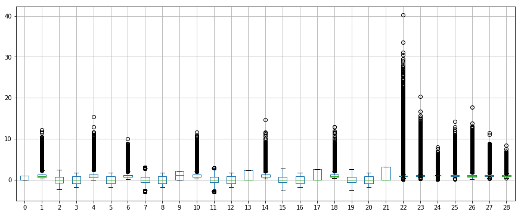

```python
%matplotlib inline
#To switch to seaborn defaults, simply call the set() function:
sns.set()
plt.rcParams['figure.figsize']=(15,6)

# boxplot for explanatory variables
data.boxplot() #
```

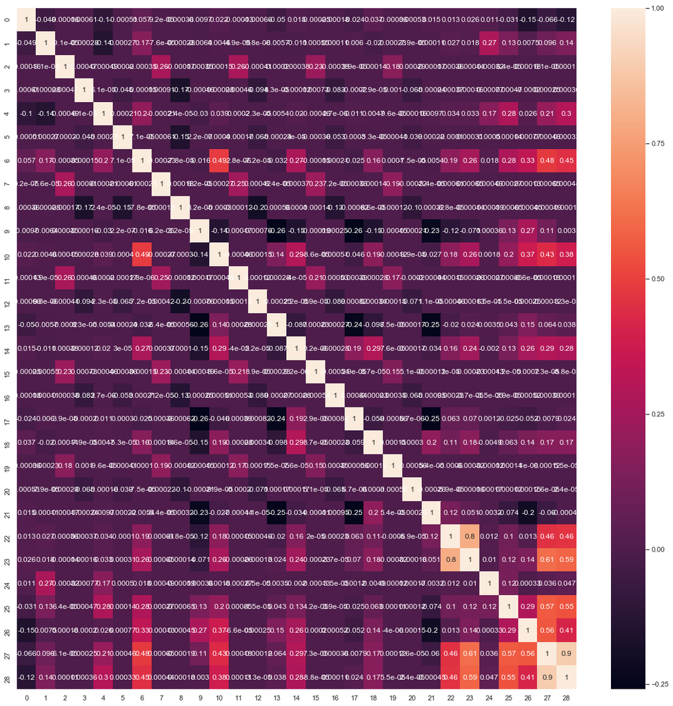

```python
#To switch to seaborn defaults, simply call the set() function:
sns.set()
plt.figure(figsize=(20,20))
sns.heatmap(data.corr(), annot =True)
```

From this correlation map, columns 27 and 28 are highly correlated. Columns 22 and 23 are also highly correlated. Columns 27 and 28 are also correlated to columns 22, 23, 25, and 26

```python
#check the ratio of default / not default
float(len(data[data[0]==1]))/len(data)*100.0 # yes = 1, no = 0
```

```
52.99634285714285
```

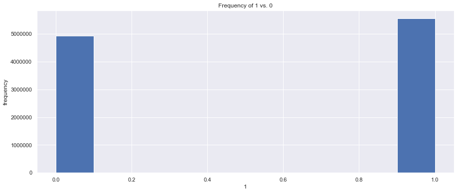

```python
#histogram plot for frequency
f,ax = plt.subplots()
df=data[0]

plt.hist(df)
plt.xlabel('1')
plt.ylabel('frequency')
plt.title("Frequency of 1 vs. 0")
plt.show()
```

Our categorical variable is slightly imbalanced with 53% of 1 value and 47% of 0 value.

## 3. Feature Important

Because our dataset is large, we find feature important in each of the portion of the dataset. The first set is the first 500,000 entries of the dataset. The second set is the 5,000,000 to 5,500,000 entry. The third set is the last 500,000 entries.

We will use Random Forest (RF) to fit our data. We do not normalize the data since RF does not require or needs to normalize the data set.

```
[0.04207743 0.02995554 0.02915881 0.03919938 0.02914264 0.05101122
 0.03040332 0.02906466 0.0075286  0.03886622 0.02997207 0.02910603
 0.00564025 0.03396501 0.02962015 0.02907947 0.00524357 0.03264183
 0.02955691 0.02916102 0.00475876 0.04052461 0.05447876 0.03194426
 0.05139839 0.10817354 0.06301958 0.06530795]
CPU times: user 10min 24s, sys: 5.68 s, total: 10min 29s
Wall time: 9min 57s
```

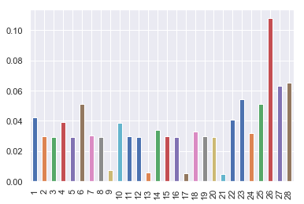

```python
%%time
from sklearn.model_selection import StratifiedKFold, cross_val_score
from sklearn.ensemble import RandomForestClassifier
from sklearn.preprocessing import StandardScaler
from sklearn import metrics as mt

from sklearn.metrics import classification_report, roc_auc_score, accuracy_score, roc_curve, auc
from sklearn import svm, datasets
from sklearn.preprocessing import label_binarize
from sklearn.multiclass import OneVsRestClassifier

from sklearn.model_selection import cross_val_score

# X_PCA = data.iloc[:,[2,3,4,5,6,7,8,9,10,11,12, 13,14,15,16,17,18,19,20,21,22,23,24,25,26,27,28]] #all the continuous
# y_PCA = data.ix[:,[0]] # iloc[row slicing, column slicing], data.ix[:,[0]].values
columns = ["1", "2","3","4","5","6","7","8","9","10","11","12","13","14","15","16","17","18","19","20","21","22","23","24","25","26","27","28"]

y_WT = np.array(data.loc[:500000,0])
x_WT = np.array(data.loc[:500000,1:])

forest = RandomForestClassifier(n_estimators=150,random_state=1)
forest.fit(x_WT, y_WT)
# importances = forest.feature_importances_

print(forest.feature_importances_) # call .cross_val_score() to get this .feature_importances_()
weights = pd.Series(forest.feature_importances_, index=columns) # index=["1", "2","3","4","5","6","7","8","9","10","11","12","13","14","15","16","17","18","19","20","21","22","23","24","25","26","27","28"]
plt.figure(figsize=(6,4))
weights.plot(kind='bar')
```

```
[0.04195935 0.02977916 0.02895869 0.03996076 0.02886506 0.05184118
 0.03011824 0.02892815 0.00733041 0.03893921 0.02976937 0.02897953
 0.00556007 0.03369934 0.02939901 0.0291236  0.00526329 0.032409
 0.02948093 0.02889971 0.00474753 0.04080355 0.05493966 0.03188119
 0.05126884 0.10904104 0.06295632 0.06509783]
CPU times: user 10min 34s, sys: 6.96 s, total: 10min 41s
Wall time: 16min 51s
```

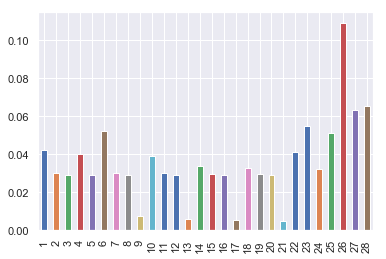

```python
%%time
from sklearn.model_selection import StratifiedKFold, cross_val_score
from sklearn.ensemble import RandomForestClassifier
from sklearn.preprocessing import StandardScaler
from sklearn import metrics as mt

from sklearn.metrics import classification_report, roc_auc_score, accuracy_score, roc_curve, auc
from sklearn import svm, datasets
from sklearn.preprocessing import label_binarize
from sklearn.multiclass import OneVsRestClassifier

from sklearn.model_selection import cross_val_score

# X_PCA = data.iloc[:,[2,3,4,5,6,7,8,9,10,11,12, 13,14,15,16,17,18,19,20,21,22,23,24,25,26,27,28]] #all the continuous
# y_PCA = data.ix[:,[0]] # iloc[row slicing, column slicing], data.ix[:,[0]].values
columns = ["1", "2","3","4","5","6","7","8","9","10","11","12","13","14","15","16","17","18","19","20","21","22","23","24","25","26","27","28"]

y_WT = np.array(data.loc[5000000:5500000,0])
x_WT = np.array(data.loc[5000000:5500000,1:])

forest = RandomForestClassifier(n_estimators=150,random_state=1)
forest.fit(x_WT, y_WT)
# importances = forest.feature_importances_

print(forest.feature_importances_) # call .cross_val_score() to get this .feature_importances_()
weights = pd.Series(forest.feature_importances_, index=columns) # index=["1","2", "3", "4", "5", "6", "7", "8", "9", "10"]
plt.figure(figsize=(6,4))
weights.plot(kind='bar')
```

```
[0.04246097 0.02986289 0.02902299 0.03991857 0.02907049 0.05111384
 0.03026493 0.02908242 0.0075155  0.03906053 0.02971678 0.02914654
 0.00551643 0.03380018 0.02945456 0.02900756 0.00523934 0.03255733
 0.02943051 0.02916043 0.00483129 0.04037413 0.05579542 0.03194396
 0.05238262 0.1070977  0.06225112 0.06492097]
CPU times: user 10min 39s, sys: 7.08 s, total: 10min 46s
Wall time: 10min 17s
```

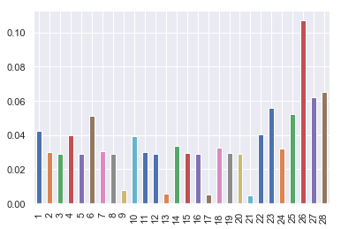

```python
%%time
from sklearn.model_selection import StratifiedKFold, cross_val_score
from sklearn.ensemble import RandomForestClassifier
from sklearn.preprocessing import StandardScaler
from sklearn import metrics as mt

from sklearn.metrics import classification_report, roc_auc_score, accuracy_score, roc_curve, auc
from sklearn import svm, datasets
from sklearn.preprocessing import label_binarize
from sklearn.multiclass import OneVsRestClassifier

from sklearn.model_selection import cross_val_score

# X_PCA = data.iloc[:,[2,3,4,5,6,7,8,9,10,11,12, 13,14,15,16,17,18,19,20,21,22,23,24,25,26,27,28]] #all the continuous
# y_PCA = data.ix[:,[0]] # iloc[row slicing, column slicing], data.ix[:,[0]].values
columns = ["1", "2","3","4","5","6","7","8","9","10","11","12","13","14","15","16","17","18","19","20","21","22","23","24","25","26","27","28"]

y_WT = np.array(data.loc[10000000:10500000,0])
x_WT = np.array(data.loc[10000000:10500000,1:])

forest = RandomForestClassifier(n_estimators=150,random_state=1)
forest.fit(x_WT, y_WT)
# importances = forest.feature_importances_

print(forest.feature_importances_) # call .cross_val_score() to get this .feature_importances_()
weights = pd.Series(forest.feature_importances_, index=columns) # index=["1","2", "3", "4", "5", "6", "7", "8", "9", "10"]
plt.figure(figsize=(6,4))
weights.plot(kind='bar')
```

All 3 subsets have the very similar pattern of variable weight. In all 3 subsets, columns 6, 23, 25, 26, 27, 28 have the heaviest weight. Column 26 variable has the biggest weight.

The score tells us how much each feature influences the response variable. The higher the value in absolute value, the higher the influence on the response variable.

However, from the correlation matrix, we observe that 27 and 28 are highly correlated. Columns 22 and 23 are also highly correlated. Columns 27 and 28 are also correlated to columns 22, 23, 25, and 26. In this case, the high weights of these variables does not really mean that these features have the biggest influence on the response variable.

In all 3 models, column 9, 13, 17, 21, have the lowest weight, close to 0. We are removing these columns from our dataset.

# V. Keras Deep Learning

Running this data set, there is a message for each of the epoch printing the loss and accuracy for each, followed by the final evaluation of the trained model on the training dataset. The skill of our model varies. Neural networks are a stochastic algorithm with a feature where the same algorithm on the same data can train a different model with different skill.

When loading in the data, we set the random seed to ensure that we get the same model and therefore the same results. The model of choice is Sequential(). We will vary different layer stacking configurations, activation functions, epochs and batch size , kernel initializers, and optimizers to find the best combination. To validate the models, we use the test data and the predict() function. We then compare the results based on our model with the actual results in the test data.

Implement Steps [1] - [8]:

[output not shown]

Back to top

```python
# %%time
start_time = time.time()

# Libraries
# conda install -c conda-forge keras
# conda install -c anaconda keras
from keras.models import Sequential
from keras.layers.core import Dense, Dropout, Activation
from keras.optimizers import SGD
from sklearn.metrics import roc_auc_score
from keras import optimizers

# We have initialized our random number generator to ensure our results are reproducible and loaded our data.
# random seed for reproducibility
# exclue columns 9, 13, 17, 21
seed = 7 # fix random seed for reproducibility
np.random.seed(seed)

# 1. Load Data
# split into input (x) and output (y) variables
# exclude columns 9, 13, 17, 21
y = np.array(data.loc[:,0])
x = np.array(data.loc[:,[1,2,3,4,5,6,7,8,10,11,12,14,15,16,18,19,20,22,23,24,25,26,27,28]])
x_test = np.array(test_data.loc[:,[1,2,3,4,5,6,7,8,10,11,12,14,15,16,18,19,20,22,23,24,25,26,27,28]])
y_test = np.array(test_data.loc[:,0])

# to avoid loading from csv everytime, we use np.save() to load data from .npy files instead of accessing the .csv file every time
np.save('xtrain.npy',x)
np.save('ytrain.npy',y)
np.save('xtest.npy',x_test)
np.save('ytest.npy',y_test)

# then load using:
# x = np.load('xtrain.npy')
# y = np.load('ytrain.npy')
# x_test = np.load('xtest.npy')
# y_test = np.load('ytest.npy')

# 2. Define Model
#Begin
# layer 1 - input layer
model = Sequential()
model.add(Dense(50, input_dim=x.shape[1], kernel_initializer='uniform')) # X_train.shape[1] == 28 here # 4: change kernel_initializer=
model.add(Activation('sigmoid')) # change sigmoid to "tanh" or "ReLu" or whatever you can find (googling)

# layer 2 - a hidden layer
model.add(Dropout(0.10))
model.add(Dense(50, kernel_initializer='uniform'))
model.add(Activation('sigmoid')) # change sigmoid to "tanh" or "ReLu" or whatever you can find (googling)
model.add(Dropout(0.10))

# output layer
model.add(Dense(1, kernel_initializer='uniform'))
model.add(Activation('sigmoid')) # change sigmoid to "tanh" or "ReLu" or whatever you can find (googling)

# 3. Compile model
sgd = SGD(lr=0.1, decay=1e-6, momentum=0.9, nesterov=True)
model.compile(loss='binary_crossentropy', metrics=['accuracy'], optimizer=sgd) # also, optimizer='adam'

# 4. Fit the model
model.fit(x, y, epochs=5, batch_size=1000) # you can change batch_size

# 5&6. calculater roc_auc_score
roc = roc_auc_score(y_test,model.predict(x_test)) # false positive
print roc
#end

# time
elapsed_time = time.time() - start_time
print elapsed_time
```

```
0.7745633486779668
378.881890059
```

```python
%%time
model.summary()
elapsed_time
```

```
_________________________________________________________________
Layer (type)                 Output Shape              Param #
=================================================================
dense_58 (Dense)             (None, 50)                1250
_________________________________________________________________
activation_58 (Activation)   (None, 50)                0
_________________________________________________________________
dropout_37 (Dropout)         (None, 50)                0
_________________________________________________________________
dense_59 (Dense)             (None, 50)                2550
_________________________________________________________________
activation_59 (Activation)   (None, 50)                0
_________________________________________________________________
dropout_38 (Dropout)         (None, 50)                0
_________________________________________________________________
dense_60 (Dense)             (None, 1)                 51
_________________________________________________________________
activation_60 (Activation)   (None, 1)                 0
=================================================================
Total params: 3,851
Trainable params: 3,851
Non-trainable params: 0
_________________________________________________________________
CPU times: user 4.35 ms, sys: 3.56 ms, total: 7.91 ms
Wall time: 8.08 ms
```

We do this with a batch_size of 1000 and only for 5 epochs to prevent overfits. We train the model longer later on to find the optimized parameter.

## 1. Different Layer and Neurons Architectures

Number of layers: it's difficult to know exactly how many layers and their types for any model. In this case study, we go through a process of trial and error experimentation. We will add 2, 3, 4 hidden layers to try the optimized layer structure. Between them, we are using dropout rate of 10% to prevent overfitting.

We add more layer to the model, each time with an increase of 10 neurons in the adding layer.

The net we use is Dense, meaning that each neuron in a layer is connected to all neurons located in the previous layer and to all the neurons in the following layer.

Back to top

### Adding 1 more layer of 60 neurons

```python
# %%time
start_time = time.time()

# N=10500000. #Change this line adjust the number of rows. This is an option to load a subset of the data (N=10500000 line).
# data=pd.read_csv("HIGGS.csv",nrows=N,header=None)
# test_data=pd.read_csv("HIGGS.csv",nrows=500000,header=None,skiprows=10500000)

# We have initialized our random number generator to ensure our results are reproducible and loaded our data.
# random seed for reproducibility
seed = 7 # fix random seed for reproducibility
np.random.seed(seed)

# load data using load()
# split into input (x) and output (y) variables
x = np.load('xtrain.npy')
y = np.load('ytrain.npy')
x_test = np.load('xtest.npy')
y_test = np.load('ytest.npy')

#Begin
# layer 1
model = Sequential()
model.add(Dense(50, input_dim=x.shape[1], kernel_initializer='uniform')) # X_train.shape[1] == 28 here # 4: change kernel_initializer=
model.add(Activation('sigmoid'))

# layer 2 - a hidden layer
model.add(Dropout(0.10))
model.add(Dense(50, kernel_initializer='uniform'))
model.add(Activation('sigmoid'))

# add layer 3 - a hidden layer
model.add(Dropout(0.10))
model.add(Dense(60, kernel_initializer='uniform'))
model.add(Activation('sigmoid'))

# Output has 1 neuron
model.add(Dense(1, kernel_initializer='uniform'))
model.add(Activation('sigmoid'))
#1 layer
# model.add(Dense(50, input_dim=x.shape[1], kernel_initializer='uniform')) # X_train.shape[1] == 28 here # 50 or 100 or whatever is ok
# model.add(Activation('sigmoid')) # change sigmoid to "tanh" or "ReLu" or whatever you can find (googling)
# model.add(Dropout(0.10))
### closer to 1, it's harder

sgd = SGD(lr=0.1, decay=1e-6, momentum=0.9, nesterov=True)
model.compile(loss='binary_crossentropy', metrics=['accuracy'], optimizer=sgd)

model.fit(x, y, epochs=5, batch_size=1000) # you can change batch_size and epochs
# and add validation_data = (x_test, y_test): model.fit(x, y, epochs=5, batch_size=1000, validation_data = (x_test, y_test))

roc = roc_auc_score(y_test,model.predict(x_test)) # false positive
print roc
#end

elapsed_time = time.time() - start_time
print elapsed_time
```

```
0.760862485888399
437.815129995
```

### Adding 2 more layers of 60 neurons and 70 neurons

```python
# %%time
start_time = time.time()
# We have initialized our random number generator to ensure our results are reproducible and loaded our data.
# random seed for reproducibility
seed = 7 # fix random seed for reproducibility
np.random.seed(seed)

# load data using load()
# split into input (x) and output (y) variables
x = np.load('xtrain.npy')
y = np.load('ytrain.npy')
x_test = np.load('xtest.npy')
y_test = np.load('ytest.npy')

#Begin
# layer 1
model = Sequential()
model.add(Dense(50, input_dim=x.shape[1], kernel_initializer='uniform')) # X_train.shape[1] == 28 here # 4: change kernel_initializer=
model.add(Activation('sigmoid'))

# layer 2 - a hidden layer
model.add(Dropout(0.10))
model.add(Dense(50, kernel_initializer='uniform'))
model.add(Activation('sigmoid'))

# add layer 3 - a hidden layer
model.add(Dropout(0.10))
model.add(Dense(60, kernel_initializer='uniform'))
model.add(Activation('sigmoid'))

# add layer 4 - a hidden layer
model.add(Dropout(0.10))
model.add(Dense(70, kernel_initializer='uniform'))
model.add(Activation('sigmoid'))

# Output
model.add(Dense(1, kernel_initializer='uniform'))
model.add(Activation('sigmoid'))
#1 layer
# model.add(Dense(50, input_dim=x.shape[1], kernel_initializer='uniform')) # X_train.shape[1] == 28 here # 50 or 100 or whatever is ok
# model.add(Activation('sigmoid')) # change sigmoid to "tanh" or "ReLu" or whatever you can find (googling)
# model.add(Dropout(0.10))
### closer to 1, it's harder

sgd = SGD(lr=0.1, decay=1e-6, momentum=0.9, nesterov=True)
model.compile(loss='binary_crossentropy', metrics=['accuracy'], optimizer=sgd)

model.fit(x, y, epochs=5, batch_size=1000) # you can change batch_size and epochs
# and add validation_data = (x_test, y_test): model.fit(x, y, epochs=5, batch_size=1000, validation_data = (x_test, y_test))

roc = roc_auc_score(y_test,model.predict(x_test)) # false positive
print roc
#end

elapsed_time = time.time() - start_time
print elapsed_time
```

```
0.5227002894821552
518.202996969
```

### Adding 3 more layers of 60, 70, and 80 neurons

```python
# %%time
start_time = time.time()
# We have initialized our random number generator to ensure our results are reproducible and loaded our data.
# random seed for reproducibility
seed = 7 # fix random seed for reproducibility
np.random.seed(seed)

# load data using load()
# split into input (x) and output (y) variables
x = np.load('xtrain.npy')
y = np.load('ytrain.npy')
x_test = np.load('xtest.npy')
y_test = np.load('ytest.npy')

#Begin
# layer 1
model = Sequential()
model.add(Dense(50, input_dim=x.shape[1], kernel_initializer='uniform')) # X_train.shape[1] == 28 here # 4: change kernel_initializer=
model.add(Activation('sigmoid'))

# layer 2 - a hidden layer
model.add(Dropout(0.10))
model.add(Dense(50, kernel_initializer='uniform'))
model.add(Activation('sigmoid'))

# add layer 3 - a hidden layer
model.add(Dropout(0.10))
model.add(Dense(60, kernel_initializer='uniform'))
model.add(Activation('sigmoid'))

# add layer 4 - a hidden layer
model.add(Dropout(0.10))
model.add(Dense(70, kernel_initializer='uniform'))
model.add(Activation('sigmoid'))

# add layer 5 - a hidden layer
model.add(Dropout(0.10))
model.add(Dense(80, kernel_initializer='uniform'))
model.add(Activation('sigmoid'))

# Output
model.add(Dense(1, kernel_initializer='uniform'))
model.add(Activation('sigmoid'))
#1 layer
# model.add(Dense(50, input_dim=x.shape[1], kernel_initializer='uniform')) # X_train.shape[1] == 28 here # 50 or 100 or whatever is ok
# model.add(Activation('sigmoid')) # change sigmoid to "tanh" or "ReLu" or whatever you can find (googling)
# model.add(Dropout(0.10))
### closer to 1, it's harder

sgd = SGD(lr=0.1, decay=1e-6, momentum=0.9, nesterov=True)
model.compile(loss='binary_crossentropy', metrics=['accuracy'], optimizer=sgd)

model.fit(x, y, epochs=5, batch_size=1000) # you can change batch_size and epochs
# and add validation_data = (x_test, y_test): model.fit(x, y, epochs=5, batch_size=1000, validation_data = (x_test, y_test))

roc = roc_auc_score(y_test,model.predict(x_test)) # false positive
print roc
#end

elapsed_time = time.time() - start_time
print elapsed_time
```

```
0.5
666.834860802
```

Adding more layers and neurons does not give better roc for our data set. The best model has 1 input layer, 1 hidden layer, 1 output layer.

### 3 layers structure with an increased number of neuron (60 neurons) in 2nd layer

```python
# %%time
start_time = time.time()
# We have initialized our random number generator to ensure our results are reproducible and loaded our data.
# random seed for reproducibility
seed = 7 # fix random seed for reproducibility
np.random.seed(seed)

# # split into input (x) and output (y) variables
# y = np.array(data.loc[:,0])
# x = np.array(data.loc[:,1:])
# x_test = np.array(test_data.loc[:,1:])
# y_test = np.array(test_data.loc[:,0])

# load data using load()
# split into input (x) and output (y) variables
x = np.load('xtrain.npy')
y = np.load('ytrain.npy')
x_test = np.load('xtest.npy')
y_test = np.load('ytest.npy')

#Begin
# layer 1
model = Sequential()
model.add(Dense(50, input_dim=x.shape[1], kernel_initializer='uniform')) # X_train.shape[1] == 28 here # 4: change kernel_initializer=
model.add(Activation('sigmoid'))

# layer 2 - a hidden layer
model.add(Dropout(0.10))
model.add(Dense(60, kernel_initializer='uniform'))
model.add(Activation('sigmoid'))

# Output
model.add(Dense(1, kernel_initializer='uniform'))
model.add(Activation('sigmoid'))
#1 layer
# model.add(Dense(50, input_dim=x.shape[1], kernel_initializer='uniform')) # X_train.shape[1] == 28 here # 50 or 100 or whatever is ok
# model.add(Activation('sigmoid')) # change sigmoid to "tanh" or "ReLu" or whatever you can find (googling)
# model.add(Dropout(0.10))
### closer to 1, it's harder

sgd = SGD(lr=0.1, decay=1e-6, momentum=0.9, nesterov=True)
model.compile(loss='binary_crossentropy', metrics=['accuracy'], optimizer=sgd)

model.fit(x, y, epochs=5, batch_size=1000) # you can change batch_size and epochs
# and add validation_data = (x_test, y_test): model.fit(x, y, epochs=5, batch_size=1000, validation_data = (x_test, y_test))

roc = roc_auc_score(y_test,model.predict(x_test)) # false positive
print roc
#end

elapsed_time = time.time() - start_time
print elapsed_time
# start_time = time.time()
```

```
0.781441679994729
380.259068966
```

With an increase of neuron in 2nd layer to 60 neurons, the model performs better with roc of 0.7814. It takes a little bit longer to train this model compare to the model with 50 neurons in the 2nd layer. The more layer added, the longer the training time.

Summary Table

| Layers# | Neurons# | upper layers' activation func | output layer's activation func | kernel | batch size | optimizer | epochs | ROC | elapsed time |
| --- | --- | --- | --- | --- | --- | --- | --- | --- | --- |
| 3 | 50-50-1 | sigmoid | sigmoid | uniform | 1000 | sgd | 5 | 0.77456 | 378.88 |
| 3 | 50-60-1 | sigmoid | sigmoid | uniform | 1000 | sgd | 5 | **0.7814** | 380.26 |
| 4 | 50-50-60-1 | sigmoid | sigmoid | uniform | 1000 | sgd | 5 | 0.76086 | 437.82 |
| 5 | 50-50-60-70-1 | sigmoid | sigmoid | uniform | 1000 | sgd | 5 | 0.52270 | 518.20 |
| 6 | 50-50-60-70-80-1 | sigmoid | sigmoid | uniform | 1000 | sgd | 5 | 0.5 | 666.83 |

## 2. Activation Function Optimization

```
- Sigmoid: neuron can use the sigmoid for computing the nonlinear function. A neuron with sigmoid activation has a behavior similar to the perceptron, but the changes are gradual and output values.
- Tanh: is a hyperbolic tangent activation function.
- Rectified linear unit (ReLU): is a simple, nonlinear function. The function is zero for negative values, and it grows linearly for positive values.
- Softmax: is a generalization of the sigmoid function. Softmax squashes a k-dimensional vector of arbitrary real values into a k-dimensional vector of real values in the range (0, 1). In our case, it aggregates 50 answers provided by the previous layer with 50 neurons.
```

Back to top

### Tanh activation function:

**3 layers model and 50-50-1 neurons structure**

```python
# %%time
# **3 layers model and 50-50-1 neurons structure**
start_time = time.time()
# original model of 3 layers and 50-50-1 neurons structure
# We have initialized our random number generator to ensure our results are reproducible and loaded our data.
# random seed for reproducibility
seed = 7 # fix random seed for reproducibility
np.random.seed(seed)

# # split into input (x) and output (y) variables
# y = np.array(data.loc[:,0])
# x = np.array(data.loc[:,1:])
# x_test = np.array(test_data.loc[:,1:])
# y_test = np.array(test_data.loc[:,0])

# load data using load()
# split into input (x) and output (y) variables
x = np.load('xtrain.npy')
y = np.load('ytrain.npy')
x_test = np.load('xtest.npy')
y_test = np.load('ytest.npy')

#Begin
# layer 1
model = Sequential()
model.add(Dense(50, input_dim=x.shape[1], kernel_initializer='uniform')) # X_train.shape[1] == 28 here # 4: change kernel_initializer=
model.add(Activation('tanh'))

# layer 2 - a hidden layer
model.add(Dropout(0.10))
model.add(Dense(50, kernel_initializer='uniform'))
model.add(Activation('tanh'))

# Output
model.add(Dense(1, kernel_initializer='uniform'))
model.add(Activation('tanh'))
#1 layer
# model.add(Dense(50, input_dim=x.shape[1], kernel_initializer='uniform')) # X_train.shape[1] == 28 here # 50 or 100 or whatever is ok
# model.add(Activation('sigmoid')) # change sigmoid to "tanh" or "ReLu" or whatever you can find (googling)
# model.add(Dropout(0.10))
### closer to 1, it's harder

sgd = SGD(lr=0.1, decay=1e-6, momentum=0.9, nesterov=True)
model.compile(loss='binary_crossentropy', metrics=['accuracy'], optimizer=sgd)

model.fit(x, y, epochs=5, batch_size=1000) # you can change batch_size and epochs
# and add validation_data = (x_test, y_test): model.fit(x, y, epochs=5, batch_size=1000, validation_data = (x_test, y_test))

roc = roc_auc_score(y_test,model.predict(x_test)) # false positive
print roc
#end

elapsed_time = time.time() - start_time
print elapsed_time
# start_time = time.time()
```

```
0.5
383.919224977
```

**4 layers model and 50-50-60-1 neurons structure**

```python
# %%time
# 4 layers model and 50-50-60-1 neurons structure
start_time = time.time()
# We have initialized our random number generator to ensure our results are reproducible and loaded our data.
# random seed for reproducibility
seed = 7 # fix random seed for reproducibility
np.random.seed(seed)

# # split into input (x) and output (y) variables
# y = np.array(data.loc[:,0])
# x = np.array(data.loc[:,1:])
# x_test = np.array(test_data.loc[:,1:])
# y_test = np.array(test_data.loc[:,0])

# load data using load()
# split into input (x) and output (y) variables
x = np.load('xtrain.npy')
y = np.load('ytrain.npy')
x_test = np.load('xtest.npy')
y_test = np.load('ytest.npy')

#Begin
# layer 1
model = Sequential()
model.add(Dense(50, input_dim=x.shape[1], kernel_initializer='uniform')) # X_train.shape[1] == 28 here # 4: change kernel_initializer=
model.add(Activation('tanh'))

# layer 2 - a hidden layer
model.add(Dropout(0.10))
model.add(Dense(50, kernel_initializer='uniform'))
model.add(Activation('tanh'))

# add layer 3 - a hidden layer
model.add(Dropout(0.10))
model.add(Dense(60, kernel_initializer='uniform'))
model.add(Activation('tanh'))

# Output
model.add(Dense(1, kernel_initializer='uniform'))
model.add(Activation('tanh'))
#1 layer
# model.add(Dense(50, input_dim=x.shape[1], kernel_initializer='uniform')) # X_train.shape[1] == 28 here # 50 or 100 or whatever is ok
# model.add(Activation('sigmoid')) # change sigmoid to "tanh" or "ReLu" or whatever you can find (googling)
# model.add(Dropout(0.10))
### closer to 1, it's harder

sgd = SGD(lr=0.1, decay=1e-6, momentum=0.9, nesterov=True)
model.compile(loss='binary_crossentropy', metrics=['accuracy'], optimizer=sgd)

model.fit(x, y, epochs=5, batch_size=1000) # you can change batch_size and epochs
# and add validation_data = (x_test, y_test): model.fit(x, y, epochs=5, batch_size=1000, validation_data = (x_test, y_test))

roc = roc_auc_score(y_test,model.predict(x_test)) # false positive
print roc
#end

elapsed_time = time.time() - start_time
print elapsed_time
# start_time = time.time()
```

```
0.5
443.046951056
```

**5 layers model and 50-50-60-70-1 neurons structure**

```python
# %%time
# 5 layers model and 50-50-60-70-1 neurons structure
start_time = time.time()
# We have initialized our random number generator to ensure our results are reproducible and loaded our data.
# random seed for reproducibility
seed = 7 # fix random seed for reproducibility
np.random.seed(seed)

# load data using load()
# split into input (x) and output (y) variables
x = np.load('xtrain.npy')
y = np.load('ytrain.npy')
x_test = np.load('xtest.npy')
y_test = np.load('ytest.npy')

#Begin
# layer 1
model = Sequential()
model.add(Dense(50, input_dim=x.shape[1], kernel_initializer='uniform')) # X_train.shape[1] == 28 here # 4: change kernel_initializer=
model.add(Activation('tanh'))

# layer 2 - a hidden layer
model.add(Dropout(0.10))
model.add(Dense(50, kernel_initializer='uniform'))
model.add(Activation('tanh'))

# add layer 3 - a hidden layer
model.add(Dropout(0.10))
model.add(Dense(60, kernel_initializer='uniform'))
model.add(Activation('tanh'))

# add layer 4 - a hidden layer
model.add(Dropout(0.10))
model.add(Dense(70, kernel_initializer='uniform'))
model.add(Activation('tanh'))

# Output
model.add(Dense(1, kernel_initializer='uniform'))
model.add(Activation('tanh'))

sgd = SGD(lr=0.1, decay=1e-6, momentum=0.9, nesterov=True)
model.compile(loss='binary_crossentropy', metrics=['accuracy'], optimizer=sgd)

model.fit(x, y, epochs=5, batch_size=1000) # you can change batch_size and epochs
# and add validation_data = (x_test, y_test): model.fit(x, y, epochs=5, batch_size=1000, validation_data = (x_test, y_test))

roc = roc_auc_score(y_test,model.predict(x_test)) # false positive
print roc
#end

elapsed_time = time.time() - start_time
print elapsed_time
# start_time = time.time()
```

```
0.5
530.801619053
```

**6 layers model and 50-50-60-70-80-1 neurons structure**

```python
# %%time
# 6 layers model and 50-50-60-70-80-1 neurons structure
start_time = time.time()
# We have initialized our random number generator to ensure our results are reproducible and loaded our data.
# random seed for reproducibility
seed = 7 # fix random seed for reproducibility
np.random.seed(seed)

# load data using load()
# split into input (x) and output (y) variables
x = np.load('xtrain.npy')
y = np.load('ytrain.npy')
x_test = np.load('xtest.npy')
y_test = np.load('ytest.npy')

#Begin
# layer 1
model = Sequential()
model.add(Dense(50, input_dim=x.shape[1], kernel_initializer='uniform')) # X_train.shape[1] == 28 here # 4: change kernel_initializer=
model.add(Activation('tanh'))

# layer 2 - a hidden layer
model.add(Dropout(0.10))
model.add(Dense(50, kernel_initializer='uniform'))
model.add(Activation('tanh'))

# add layer 3 - a hidden layer
model.add(Dropout(0.10))
model.add(Dense(60, kernel_initializer='uniform'))
model.add(Activation('tanh'))

# add layer 4 - a hidden layer
model.add(Dropout(0.10))
model.add(Dense(70, kernel_initializer='uniform'))
model.add(Activation('tanh'))

# add layer 5 - a hidden layer
model.add(Dropout(0.10))
model.add(Dense(80, kernel_initializer='uniform'))
model.add(Activation('tanh'))

# Output
model.add(Dense(1, kernel_initializer='uniform'))
model.add(Activation('tanh'))

sgd = SGD(lr=0.1, decay=1e-6, momentum=0.9, nesterov=True)
model.compile(loss='binary_crossentropy', metrics=['accuracy'], optimizer=sgd)

model.fit(x, y, epochs=5, batch_size=1000) # you can change batch_size and epochs
# and add validation_data = (x_test, y_test): model.fit(x, y, epochs=5, batch_size=1000, validation_data = (x_test, y_test))

roc = roc_auc_score(y_test,model.predict(x_test)) # false positive
print roc
#end

elapsed_time = time.time() - start_time
print elapsed_time
# start_time = time.time()
```

```
0.5
647.598028183
```

**The 3 layers structure with 60 neurons at layer 2**

```python
# %%time
# The 3 layers structure with 60 neurons at layer 2
start_time = time.time()
# We have initialized our random number generator to ensure our results are reproducible and loaded our data.
# random seed for reproducibility
seed = 7 # fix random seed for reproducibility
np.random.seed(seed)

# # split into input (x) and output (y) variables
# y = np.array(data.loc[:,0])
# x = np.array(data.loc[:,1:])
# x_test = np.array(test_data.loc[:,1:])
# y_test = np.array(test_data.loc[:,0])

# load data using load()
# split into input (x) and output (y) variables
x = np.load('xtrain.npy')
y = np.load('ytrain.npy')
x_test = np.load('xtest.npy')
y_test = np.load('ytest.npy')

#Begin
# layer 1
model = Sequential()
model.add(Dense(50, input_dim=x.shape[1], kernel_initializer='uniform')) # X_train.shape[1] == 28 here # 4: change kernel_initializer=
model.add(Activation('sigmoid'))

# layer 2 - a hidden layer
model.add(Dropout(0.10))
model.add(Dense(60, kernel_initializer='uniform'))
model.add(Activation('sigmoid'))

# Output
model.add(Dense(1, kernel_initializer='uniform'))
model.add(Activation('sigmoid'))
#1 layer
# model.add(Dense(50, input_dim=x.shape[1], kernel_initializer='uniform')) # X_train.shape[1] == 28 here # 50 or 100 or whatever is ok
# model.add(Activation('sigmoid')) # change sigmoid to "tanh" or "ReLu" or whatever you can find (googling)
# model.add(Dropout(0.10))
### closer to 1, it's harder

sgd = SGD(lr=0.1, decay=1e-6, momentum=0.9, nesterov=True)
model.compile(loss='binary_crossentropy', metrics=['accuracy'], optimizer=sgd)

model.fit(x, y, epochs=5, batch_size=1000) # you can change batch_size and epochs
# and add validation_data = (x_test, y_test): model.fit(x, y, epochs=5, batch_size=1000, validation_data = (x_test, y_test))

roc = roc_auc_score(y_test,model.predict(x_test)) # false positive
print roc
#end

elapsed_time = time.time() - start_time
print elapsed_time
# start_time = time.time()
```

```
0.7814735614595528
470.350820065
```

Summary Table

[output not shown]

Back to top

### ReLu activation function:

**3 layers model and 50-50-1 neurons structure**

Back to top

```python
# %%time
# 3 layers model and 50-50-1 neurons structure
start_time = time.time()
# We have initialized our random number generator to ensure our results are reproducible and loaded our data.
# random seed for reproducibility
seed = 7 # fix random seed for reproducibility
np.random.seed(seed)

# load data using load()
# split into input (x) and output (y) variables
x = np.load('xtrain.npy')
y = np.load('ytrain.npy')
x_test = np.load('xtest.npy')
y_test = np.load('ytest.npy')

#Begin
# layer 1
model = Sequential()
model.add(Dense(50, input_dim=x.shape[1], kernel_initializer='uniform')) # X_train.shape[1] == 28 here # 4: change kernel_initializer=
model.add(Activation('relu'))

# layer 2 - a hidden layer
model.add(Dropout(0.10))
model.add(Dense(50, kernel_initializer='uniform'))
model.add(Activation('relu'))

# Output
model.add(Dense(1, kernel_initializer='uniform'))
model.add(Activation('relu'))

sgd = SGD(lr=0.1, decay=1e-6, momentum=0.9, nesterov=True)
model.compile(loss='binary_crossentropy', metrics=['accuracy'], optimizer=sgd)

model.fit(x, y, epochs=5, batch_size=1000) # you can change batch_size and epochs
# and add validation_data = (x_test, y_test): model.fit(x, y, epochs=5, batch_size=1000, validation_data = (x_test, y_test))

roc = roc_auc_score(y_test,model.predict(x_test)) # false positive
print roc
#end

elapsed_time = time.time() - start_time
print elapsed_time
# start_time = time.time()
```

```
0.48243434528652585
352.144402981
```

**4 layers model and 50-50-60-1 neurons structure**

```python
# %%time
# 4 layers model and 50-50-60-1 neurons structure
start_time = time.time()
# We have initialized our random number generator to ensure our results are reproducible and loaded our data.
# random seed for reproducibility
seed = 7 # fix random seed for reproducibility
np.random.seed(seed)

# # split into input (x) and output (y) variables
# y = np.array(data.loc[:,0])
# x = np.array(data.loc[:,1:])
# x_test = np.array(test_data.loc[:,1:])
# y_test = np.array(test_data.loc[:,0])

# load data using load()
# split into input (x) and output (y) variables
x = np.load('xtrain.npy')
y = np.load('ytrain.npy')
x_test = np.load('xtest.npy')
y_test = np.load('ytest.npy')

#Begin
# layer 1
model = Sequential()
model.add(Dense(50, input_dim=x.shape[1], kernel_initializer='uniform')) # X_train.shape[1] == 28 here # 4: change kernel_initializer=
model.add(Activation('relu'))

# layer 2 - a hidden layer
model.add(Dropout(0.10))
model.add(Dense(50, kernel_initializer='uniform'))
model.add(Activation('relu'))

# add layer 3 - a hidden layer
model.add(Dropout(0.10))
model.add(Dense(60, kernel_initializer='uniform'))
model.add(Activation('relu'))

# Output
model.add(Dense(1, kernel_initializer='uniform'))
model.add(Activation('relu'))

sgd = SGD(lr=0.1, decay=1e-6, momentum=0.9, nesterov=True)
model.compile(loss='binary_crossentropy', metrics=['accuracy'], optimizer=sgd)

model.fit(x, y, epochs=5, batch_size=1000) # you can change batch_size and epochs
# and add validation_data = (x_test, y_test): model.fit(x, y, epochs=5, batch_size=1000, validation_data = (x_test, y_test))

roc = roc_auc_score(y_test,model.predict(x_test)) # false positive
print roc
#end

elapsed_time = time.time() - start_time
print elapsed_time
# start_time = time.time()
```

```
0.48345186040908505
562.808797121
```

**5 layers model and 50-50-60-70-1 neurons structure**

```python
# %%time
# 5 layers model and 50-50-60-70-1 neurons structure
start_time = time.time()
# We have initialized our random number generator to ensure our results are reproducible and loaded our data.
# random seed for reproducibility
seed = 7 # fix random seed for reproducibility
np.random.seed(seed)

# load data using load()
# split into input (x) and output (y) variables
x = np.load('xtrain.npy')
y = np.load('ytrain.npy')
x_test = np.load('xtest.npy')
y_test = np.load('ytest.npy')

#Begin
# layer 1
model = Sequential()
model.add(Dense(50, input_dim=x.shape[1], kernel_initializer='uniform')) # X_train.shape[1] == 28 here # 4: change kernel_initializer=
model.add(Activation('relu'))

# layer 2 - a hidden layer
model.add(Dropout(0.10))
model.add(Dense(50, kernel_initializer='uniform'))
model.add(Activation('relu'))

# add layer 3 - a hidden layer
model.add(Dropout(0.10))
model.add(Dense(60, kernel_initializer='uniform'))
model.add(Activation('relu'))

# add layer 4 - a hidden layer
model.add(Dropout(0.10))
model.add(Dense(70, kernel_initializer='uniform'))
model.add(Activation('relu'))

# Output
model.add(Dense(1, kernel_initializer='uniform'))
model.add(Activation('relu'))

sgd = SGD(lr=0.1, decay=1e-6, momentum=0.9, nesterov=True)
model.compile(loss='binary_crossentropy', metrics=['accuracy'], optimizer=sgd)

model.fit(x, y, epochs=5, batch_size=1000) # you can change batch_size and epochs
# and add validation_data = (x_test, y_test): model.fit(x, y, epochs=5, batch_size=1000, validation_data = (x_test, y_test))

roc = roc_auc_score(y_test,model.predict(x_test)) # false positive
print roc
#end

elapsed_time = time.time() - start_time
print elapsed_time
# start_time = time.time()
```

```
0.48238429118993004
565.546808004
```

**6 layers model and 50-50-60-70-80-1 neurons structure**

```python
# %%time
# 6 layers model and 50-50-60-70-80-1 neurons structure
start_time = time.time()
# We have initialized our random number generator to ensure our results are reproducible and loaded our data.
# random seed for reproducibility
seed = 7 # fix random seed for reproducibility
np.random.seed(seed)

# load data using load()
# split into input (x) and output (y) variables
x = np.load('xtrain.npy')
y = np.load('ytrain.npy')
x_test = np.load('xtest.npy')
y_test = np.load('ytest.npy')

#Begin
# layer 1
model = Sequential()
model.add(Dense(50, input_dim=x.shape[1], kernel_initializer='uniform')) # X_train.shape[1] == 28 here # 4: change kernel_initializer=
model.add(Activation('tanh'))

# layer 2 - a hidden layer
model.add(Dropout(0.10))
model.add(Dense(50, kernel_initializer='uniform'))
model.add(Activation('relu'))

# add layer 3 - a hidden layer
model.add(Dropout(0.10))
model.add(Dense(60, kernel_initializer='uniform'))
model.add(Activation('relu'))

# add layer 4 - a hidden layer
model.add(Dropout(0.10))
model.add(Dense(70, kernel_initializer='uniform'))
model.add(Activation('relu'))

# add layer 5 - a hidden layer
model.add(Dropout(0.10))
model.add(Dense(80, kernel_initializer='uniform'))
model.add(Activation('relu'))

# Output
model.add(Dense(1, kernel_initializer='uniform'))
model.add(Activation('relu'))

sgd = SGD(lr=0.1, decay=1e-6, momentum=0.9, nesterov=True)
model.compile(loss='binary_crossentropy', metrics=['accuracy'], optimizer=sgd)

model.fit(x, y, epochs=5, batch_size=1000) # you can change batch_size and epochs
# and add validation_data = (x_test, y_test): model.fit(x, y, epochs=5, batch_size=1000, validation_data = (x_test, y_test))

roc = roc_auc_score(y_test,model.predict(x_test)) # false positive
print roc
#end

elapsed_time = time.time() - start_time
print elapsed_time
# start_time = time.time()
```

```
0.5057939980649386
829.970628977
```

**The 3 layers structure with 60 neurons at layer 2**

```python
# %%time
# The 3 layers structure with 60 neurons at layer 2
start_time = time.time()
# We have initialized our random number generator to ensure our results are reproducible and loaded our data.
# random seed for reproducibility
seed = 7 # fix random seed for reproducibility
np.random.seed(seed)

# load data using load()
# split into input (x) and output (y) variables
x = np.load('xtrain.npy')
y = np.load('ytrain.npy')
x_test = np.load('xtest.npy')
y_test = np.load('ytest.npy')

#Begin
# layer 1
model = Sequential()
model.add(Dense(50, input_dim=x.shape[1], kernel_initializer='uniform')) # X_train.shape[1] == 28 here # 4: change kernel_initializer=
model.add(Activation('relu'))

# layer 2 - a hidden layer
model.add(Dropout(0.10))
model.add(Dense(60, kernel_initializer='uniform'))
model.add(Activation('relu'))

# Output
model.add(Dense(1, kernel_initializer='uniform'))
model.add(Activation('relu'))


sgd = SGD(lr=0.1, decay=1e-6, momentum=0.9, nesterov=True)
model.compile(loss='binary_crossentropy', metrics=['accuracy'], optimizer=sgd)

model.fit(x, y, epochs=5, batch_size=1000) # you can change batch_size and epochs
# and add validation_data = (x_test, y_test): model.fit(x, y, epochs=5, batch_size=1000, validation_data = (x_test, y_test))

roc = roc_auc_score(y_test,model.predict(x_test)) # false positive
print roc
#end

elapsed_time = time.time() - start_time
print elapsed_time
# start_time = time.time()
```

```
0.5
397.618155956
```

Summary Table

[output not shown]

Back to top

### Softmax activation function

**3 layers model and 50-50-1 neurons structure**

```python
# %%time
# 3 layers model and 50-50-1 neurons structure
start_time = time.time()
# We have initialized our random number generator to ensure our results are reproducible and loaded our data.
# random seed for reproducibility
seed = 7 # fix random seed for reproducibility
np.random.seed(seed)

# load data using load()
# split into input (x) and output (y) variables
x = np.load('xtrain.npy')
y = np.load('ytrain.npy')
x_test = np.load('xtest.npy')
y_test = np.load('ytest.npy')

#Begin
# layer 1
model = Sequential()
model.add(Dense(50, input_dim=x.shape[1], kernel_initializer='uniform')) # X_train.shape[1] == 28 here # 4: change kernel_initializer=
model.add(Activation('softmax'))

# layer 2 - a hidden layer
model.add(Dropout(0.10))
model.add(Dense(50, kernel_initializer='uniform'))
model.add(Activation('softmax'))

# Output
model.add(Dense(1, kernel_initializer='uniform'))
model.add(Activation('softmax'))

sgd = SGD(lr=0.1, decay=1e-6, momentum=0.9, nesterov=True)
model.compile(loss='binary_crossentropy', metrics=['accuracy'], optimizer=sgd)

model.fit(x, y, epochs=5, batch_size=1000) # you can change batch_size and epochs
# and add validation_data = (x_test, y_test): model.fit(x, y, epochs=5, batch_size=1000, validation_data = (x_test, y_test))

roc = roc_auc_score(y_test,model.predict(x_test)) # false positive
print roc
#end

elapsed_time = time.time() - start_time
print elapsed_time
# start_time = time.time()
```

```
0.5
1546.18874598
```

**4 layers model and 50-50-60-1 neurons structure**

```python
# %%time
# 4 layers model and 50-50-60-1 neurons structure
start_time = time.time()
# We have initialized our random number generator to ensure our results are reproducible and loaded our data.
# random seed for reproducibility
seed = 7 # fix random seed for reproducibility
np.random.seed(seed)

# load data using load()
# split into input (x) and output (y) variables
x = np.load('xtrain.npy')
y = np.load('ytrain.npy')
x_test = np.load('xtest.npy')
y_test = np.load('ytest.npy')

#Begin
# layer 1
model = Sequential()
model.add(Dense(50, input_dim=x.shape[1], kernel_initializer='uniform')) # X_train.shape[1] == 28 here # 4: change kernel_initializer=
model.add(Activation('softmax'))

# layer 2 - a hidden layer
model.add(Dropout(0.10))
model.add(Dense(50, kernel_initializer='uniform'))
model.add(Activation('softmax'))

# add layer 3 - a hidden layer
model.add(Dropout(0.10))
model.add(Dense(60, kernel_initializer='uniform'))
model.add(Activation('softmax'))

# Output
model.add(Dense(1, kernel_initializer='uniform'))
model.add(Activation('softmax'))

sgd = SGD(lr=0.1, decay=1e-6, momentum=0.9, nesterov=True)
model.compile(loss='binary_crossentropy', metrics=['accuracy'], optimizer=sgd)

model.fit(x, y, epochs=5, batch_size=1000) # you can change batch_size and epochs
# and add validation_data = (x_test, y_test): model.fit(x, y, epochs=5, batch_size=1000, validation_data = (x_test, y_test))

roc = roc_auc_score(y_test,model.predict(x_test)) # false positive
print roc
#end

elapsed_time = time.time() - start_time
print elapsed_time
# start_time = time.time()
```

```
0.5
846.483633041
```

**5 layers model and 50-50-60-70-1 neurons structure**

```python
# %%time
start_time = time.time()
# We have initialized our random number generator to ensure our results are reproducible and loaded our data.
# random seed for reproducibility
seed = 7 # fix random seed for reproducibility
np.random.seed(seed)

# load data using load()
# split into input (x) and output (y) variables
x = np.load('xtrain.npy')
y = np.load('ytrain.npy')
x_test = np.load('xtest.npy')
y_test = np.load('ytest.npy')

#Begin
# layer 1
model = Sequential()
model.add(Dense(50, input_dim=x.shape[1], kernel_initializer='uniform')) # X_train.shape[1] == 28 here # 4: change kernel_initializer=
model.add(Activation('softmax'))

# layer 2 - a hidden layer
model.add(Dropout(0.10))
model.add(Dense(50, kernel_initializer='uniform'))
model.add(Activation('softmax'))

# add layer 3 - a hidden layer
model.add(Dropout(0.10))
model.add(Dense(60, kernel_initializer='uniform'))
model.add(Activation('softmax'))

# add layer 4 - a hidden layer
model.add(Dropout(0.10))
model.add(Dense(70, kernel_initializer='uniform'))
model.add(Activation('softmax'))

# Output
model.add(Dense(1, kernel_initializer='uniform'))
model.add(Activation('softmax'))

sgd = SGD(lr=0.1, decay=1e-6, momentum=0.9, nesterov=True)
model.compile(loss='binary_crossentropy', metrics=['accuracy'], optimizer=sgd)

model.fit(x, y, epochs=5, batch_size=1000) # you can change batch_size and epochs
# and add validation_data = (x_test, y_test): model.fit(x, y, epochs=5, batch_size=1000, validation_data = (x_test, y_test))

roc = roc_auc_score(y_test,model.predict(x_test)) # false positive
print roc
#end

elapsed_time = time.time() - start_time
print elapsed_time
# start_time = time.time()
```

```
0.5
2945.50390887
```

**6 layers model and 50-50-60-70-80-1 neurons structure**

```python
# %%time
# 6 layers model and 50-50-60-70-80-1 neurons structure
start_time = time.time()
# We have initialized our random number generator to ensure our results are reproducible and loaded our data.
# random seed for reproducibility
seed = 7 # fix random seed for reproducibility
np.random.seed(seed)

# load data using load()
# split into input (x) and output (y) variables
x = np.load('xtrain.npy')
y = np.load('ytrain.npy')
x_test = np.load('xtest.npy')
y_test = np.load('ytest.npy')

#Begin
# layer 1
model = Sequential()
model.add(Dense(50, input_dim=x.shape[1], kernel_initializer='uniform')) # X_train.shape[1] == 28 here # 4: change kernel_initializer=
model.add(Activation('softmax'))

# layer 2 - a hidden layer
model.add(Dropout(0.10))
model.add(Dense(50, kernel_initializer='uniform'))
model.add(Activation('softmax'))

# add layer 3 - a hidden layer
model.add(Dropout(0.10))
model.add(Dense(60, kernel_initializer='uniform'))
model.add(Activation('softmax'))

# add layer 4 - a hidden layer
model.add(Dropout(0.10))
model.add(Dense(70, kernel_initializer='uniform'))
model.add(Activation('softmax'))

# add layer 5 - a hidden layer
model.add(Dropout(0.10))
model.add(Dense(80, kernel_initializer='uniform'))
model.add(Activation('relu'))

# Output
model.add(Dense(1, kernel_initializer='uniform'))
model.add(Activation('softmax'))

sgd = SGD(lr=0.1, decay=1e-6, momentum=0.9, nesterov=True)
model.compile(loss='binary_crossentropy', metrics=['accuracy'], optimizer=sgd)

model.fit(x, y, epochs=5, batch_size=1000) # you can change batch_size and epochs
# and add validation_data = (x_test, y_test): model.fit(x, y, epochs=5, batch_size=1000, validation_data = (x_test, y_test))

roc = roc_auc_score(y_test,model.predict(x_test)) # false positive
print roc
#end

elapsed_time = time.time() - start_time
print elapsed_time
# start_time = time.time()
```

```
0.5
813.467686892
```

**3 layers model and 50-60-1 neurons structure**

```python
# %%time
# 3 layers model and 50-60-1 neurons structure
start_time = time.time()
# We have initialized our random number generator to ensure our results are reproducible and loaded our data.
# random seed for reproducibility
seed = 7 # fix random seed for reproducibility
np.random.seed(seed)

# load data using load()
# split into input (x) and output (y) variables
x = np.load('xtrain.npy')
y = np.load('ytrain.npy')
x_test = np.load('xtest.npy')
y_test = np.load('ytest.npy')

#Begin
# layer 1
model = Sequential()
model.add(Dense(50, input_dim=x.shape[1], kernel_initializer='uniform')) # X_train.shape[1] == 28 here # 4: change kernel_initializer=
model.add(Activation('softmax'))

# layer 2 - a hidden layer
model.add(Dropout(0.10))
model.add(Dense(60, kernel_initializer='uniform'))
model.add(Activation('softmax'))

# Output
model.add(Dense(1, kernel_initializer='uniform'))
model.add(Activation('softmax'))

sgd = SGD(lr=0.1, decay=1e-6, momentum=0.9, nesterov=True)
model.compile(loss='binary_crossentropy', metrics=['accuracy'], optimizer=sgd)

model.fit(x, y, epochs=5, batch_size=1000) # you can change batch_size and epochs
# and add validation_data = (x_test, y_test): model.fit(x, y, epochs=5, batch_size=1000, validation_data = (x_test, y_test))

roc = roc_auc_score(y_test,model.predict(x_test)) # false positive
print roc
#end

elapsed_time = time.time() - start_time
print elapsed_time
# start_time = time.time()
```

```
0.5
410.578521967
```

Softmax activation function does not seem to work with our data set. ROC is 0.5 for all the configuration. The elapsed time is also much longer compared to models with relu, tanh and sigmoid as activation functions.

Due to its low roc result and long elapsed time, we will not consider softmax in the next sessions.

Summary Table

[output not shown]

Back to top

### Relu and sigmoid activation functions

**3 layers model and 50-50-1 neurons structure**

```python
# %%time
# 3 layers model and 50-50-1 neurons structure
start_time = time.time()
# We have initialized our random number generator to ensure our results are reproducible and loaded our data.
# random seed for reproducibility
seed = 7 # fix random seed for reproducibility
np.random.seed(seed)

# load data using load()
# split into input (x) and output (y) variables
x = np.load('xtrain.npy')
y = np.load('ytrain.npy')
x_test = np.load('xtest.npy')
y_test = np.load('ytest.npy')

#Begin
# layer 1
model = Sequential()
model.add(Dense(50, input_dim=x.shape[1], kernel_initializer='uniform')) # X_train.shape[1] == 28 here # 4: change kernel_initializer=
model.add(Activation('relu'))

# layer 2 - a hidden layer
model.add(Dropout(0.10))
model.add(Dense(50, kernel_initializer='uniform'))
model.add(Activation('relu'))

# Output
model.add(Dense(1, kernel_initializer='uniform'))
model.add(Activation('sigmoid'))

sgd = SGD(lr=0.1, decay=1e-6, momentum=0.9, nesterov=True)
model.compile(loss='binary_crossentropy', metrics=['accuracy'], optimizer=sgd)

model.fit(x, y, epochs=5, batch_size=1000) # you can change batch_size and epochs
# and add validation_data = (x_test, y_test): model.fit(x, y, epochs=5, batch_size=1000, validation_data = (x_test, y_test))

roc = roc_auc_score(y_test,model.predict(x_test)) # false positive
print roc
#end

elapsed_time = time.time() - start_time
print elapsed_time
# start_time = time.time()
```

```
0.8275113504605847
345.612985134
```

**4 layers model and 50-50-60-1 neurons structure**

```python
# %%time
# 4 layers model and 50-50-60-1 neurons structure
start_time = time.time()
# We have initialized our random number generator to ensure our results are reproducible and loaded our data.
# random seed for reproducibility
seed = 7 # fix random seed for reproducibility
np.random.seed(seed)

# # split into input (x) and output (y) variables
# y = np.array(data.loc[:,0])
# x = np.array(data.loc[:,1:])
# x_test = np.array(test_data.loc[:,1:])
# y_test = np.array(test_data.loc[:,0])

# load data using load()
# split into input (x) and output (y) variables
x = np.load('xtrain.npy')
y = np.load('ytrain.npy')
x_test = np.load('xtest.npy')
y_test = np.load('ytest.npy')

#Begin
# layer 1
model = Sequential()
model.add(Dense(50, input_dim=x.shape[1], kernel_initializer='uniform')) # X_train.shape[1] == 28 here # 4: change kernel_initializer=
model.add(Activation('relu'))

# layer 2 - a hidden layer
model.add(Dropout(0.10))
model.add(Dense(50, kernel_initializer='uniform'))
model.add(Activation('relu'))

# add layer 3 - a hidden layer
model.add(Dropout(0.10))
model.add(Dense(60, kernel_initializer='uniform'))
model.add(Activation('relu'))

# Output
model.add(Dense(1, kernel_initializer='uniform'))
model.add(Activation('sigmoid'))

sgd = SGD(lr=0.1, decay=1e-6, momentum=0.9, nesterov=True)
model.compile(loss='binary_crossentropy', metrics=['accuracy'], optimizer=sgd)

model.fit(x, y, epochs=5, batch_size=1000) # you can change batch_size and epochs
# and add validation_data = (x_test, y_test): model.fit(x, y, epochs=5, batch_size=1000, validation_data = (x_test, y_test))

roc = roc_auc_score(y_test,model.predict(x_test)) # false positive
print roc
#end

elapsed_time = time.time() - start_time
print elapsed_time
# start_time = time.time()
```

```
0.8282204578335239
547.884380102
```

**5 layers model and 50-50-60-70-1 neurons structure**

```python
# %%time
# 5 layers model and 50-50-60-70-1 neurons structure
start_time = time.time()
# We have initialized our random number generator to ensure our results are reproducible and loaded our data.
# random seed for reproducibility
seed = 7 # fix random seed for reproducibility
np.random.seed(seed)

# load data using load()
# split into input (x) and output (y) variables
x = np.load('xtrain.npy')
y = np.load('ytrain.npy')
x_test = np.load('xtest.npy')
y_test = np.load('ytest.npy')

#Begin
# layer 1
model = Sequential()
model.add(Dense(50, input_dim=x.shape[1], kernel_initializer='uniform')) # X_train.shape[1] == 28 here # 4: change kernel_initializer=
model.add(Activation('relu'))

# layer 2 - a hidden layer
model.add(Dropout(0.10))
model.add(Dense(50, kernel_initializer='uniform'))
model.add(Activation('relu'))

# add layer 3 - a hidden layer
model.add(Dropout(0.10))
model.add(Dense(60, kernel_initializer='uniform'))
model.add(Activation('relu'))

# add layer 4 - a hidden layer
model.add(Dropout(0.10))
model.add(Dense(70, kernel_initializer='uniform'))
model.add(Activation('relu'))

# Output
model.add(Dense(1, kernel_initializer='uniform'))
model.add(Activation('sigmoid'))

sgd = SGD(lr=0.1, decay=1e-6, momentum=0.9, nesterov=True)
model.compile(loss='binary_crossentropy', metrics=['accuracy'], optimizer=sgd)

model.fit(x, y, epochs=5, batch_size=1000) # you can change batch_size and epochs
# and add validation_data = (x_test, y_test): model.fit(x, y, epochs=5, batch_size=1000, validation_data = (x_test, y_test))

roc = roc_auc_score(y_test,model.predict(x_test)) # false positive
print roc
#end

elapsed_time = time.time() - start_time
print elapsed_time
# start_time = time.time()
```

```
0.8279641028625596
521.43175602
```

**6 layers model and 50-50-60-70-80-1 neurons structure**

```python
# %%time
# 6 layers model and 50-50-60-70-80-1 neurons structure
start_time = time.time()
# We have initialized our random number generator to ensure our results are reproducible and loaded our data.
# random seed for reproducibility
seed = 7 # fix random seed for reproducibility
np.random.seed(seed)

# load data using load()
# split into input (x) and output (y) variables
x = np.load('xtrain.npy')
y = np.load('ytrain.npy')
x_test = np.load('xtest.npy')
y_test = np.load('ytest.npy')

#Begin
# layer 1
model = Sequential()
model.add(Dense(50, input_dim=x.shape[1], kernel_initializer='uniform')) # X_train.shape[1] == 28 here # 4: change kernel_initializer=
model.add(Activation('relu'))

# layer 2 - a hidden layer
model.add(Dropout(0.10))
model.add(Dense(50, kernel_initializer='uniform'))
model.add(Activation('relu'))

# add layer 3 - a hidden layer
model.add(Dropout(0.10))
model.add(Dense(60, kernel_initializer='uniform'))
model.add(Activation('relu'))

# add layer 4 - a hidden layer
model.add(Dropout(0.10))
model.add(Dense(70, kernel_initializer='uniform'))
model.add(Activation('relu'))

# add layer 5 - a hidden layer
model.add(Dropout(0.10))
model.add(Dense(80, kernel_initializer='uniform'))
model.add(Activation('relu'))

# Output
model.add(Dense(1, kernel_initializer='uniform'))
model.add(Activation('sigmoid'))

sgd = SGD(lr=0.1, decay=1e-6, momentum=0.9, nesterov=True)
model.compile(loss='binary_crossentropy', metrics=['accuracy'], optimizer=sgd)

model.fit(x, y, epochs=5, batch_size=1000) # you can change batch_size and epochs
# and add validation_data = (x_test, y_test): model.fit(x, y, epochs=5, batch_size=1000, validation_data = (x_test, y_test))

roc = roc_auc_score(y_test,model.predict(x_test)) # false positive
print roc
#end

elapsed_time = time.time() - start_time
print elapsed_time
# start_time = time.time()
```

```
0.8291196821053597
660.576828003
```

**3 layers structure with 60 neurons at layer 2**

```python
# %%time
# The 3 layers structure with 60 neurons at layer 2
start_time = time.time()
# We have initialized our random number generator to ensure our results are reproducible and loaded our data.
# random seed for reproducibility
seed = 7 # fix random seed for reproducibility
np.random.seed(seed)

# load data using load()
# split into input (x) and output (y) variables
x = np.load('xtrain.npy')
y = np.load('ytrain.npy')
x_test = np.load('xtest.npy')
y_test = np.load('ytest.npy')

#Begin
# layer 1
model = Sequential()
model.add(Dense(50, input_dim=x.shape[1], kernel_initializer='uniform')) # X_train.shape[1] == 28 here # 4: change kernel_initializer=
model.add(Activation('relu'))

# layer 2 - a hidden layer
model.add(Dropout(0.10))
model.add(Dense(60, kernel_initializer='uniform'))
model.add(Activation('relu'))

# Output
model.add(Dense(1, kernel_initializer='uniform'))
model.add(Activation('sigmoid'))
#1 layer
# model.add(Dense(50, input_dim=x.shape[1], kernel_initializer='uniform')) # X_train.shape[1] == 28 here # 50 or 100 or whatever is ok
# model.add(Activation('sigmoid')) # change sigmoid to "tanh" or "ReLu" or whatever you can find (googling)
# model.add(Dropout(0.10))
### closer to 1, it's harder

sgd = SGD(lr=0.1, decay=1e-6, momentum=0.9, nesterov=True)
model.compile(loss='binary_crossentropy', metrics=['accuracy'], optimizer=sgd)

model.fit(x, y, epochs=5, batch_size=1000) # you can change batch_size and epochs
# and add validation_data = (x_test, y_test): model.fit(x, y, epochs=5, batch_size=1000, validation_data = (x_test, y_test))

roc = roc_auc_score(y_test,model.predict(x_test)) # false positive
print roc
#end

elapsed_time = time.time() - start_time
print elapsed_time
# start_time = time.time()
```

```
0.828443995460326
430.029493809
```

The combination of relu and sigmoid activation functions seem to work well with our dataset. The highest ROC is 0.82912 with the 6 layers structure. The elapsed time is similar to that of models with tanh and sigmoid as activation functions.

Overall, the combination of relu and sigmoid activation functions perform better than each of the sigmoid, tanh, relu, and softmax at each neuron-layer structure.

Summary Table

| Layers# | Neurons# | upper layers' activation func | output layer's activation func | kernel | batch size | optimizer | epochs | ROC | elapsed time |
| --- | --- | --- | --- | --- | --- | --- | --- | --- | --- |
| 3 | 50-50-1 | sigmoid | sigmoid | uniform | 1000 | sgd | 5 | 0.77456 | 378.88 |
| 3 | 50-60-1 | sigmoid | sigmoid | uniform | 1000 | sgd | 5 | **0.7814** | 380.26 |
| 4 | 50-50-60-1 | sigmoid | sigmoid | uniform | 1000 | sgd | 5 | 0.76086 | 437.82 |
| 5 | 50-50-60-70-1 | sigmoid | sigmoid | uniform | 1000 | sgd | 5 | 0.52270 | 518.20 |
| 6 | 50-50-60-70-80-1 | sigmoid | sigmoid | uniform | 1000 | sgd | 5 | 0.5 | 666.83 |
| 3 | 50-50-1 | tanh | tanh | uniform | 1000 | sgd | 5 | 0.5 | 383.92 |
| 3 | 50-60-1 | tanh | tanh | uniform | 1000 | sgd | 5 | **0.7814** | 470.35 |
| 4 | 50-50-60-1 | tanh | tanh | uniform | 1000 | sgd | 5 | 0.5 | 443.05 |
| 5 | 50-50-60-70-1 | tanh | tanh | uniform | 1000 | sgd | 5 | 0.5 | 530.8 |
| 6 | 50-50-60-70-80-1 | tanh | tanh | uniform | 1000 | sgd | 5 | 0.5 | 647.60 |
| 3 | 50-50-1 | Relu | Relu | uniform | 1000 | sgd | 5 | 0.48243 | 352.14 |
| 3 | 50-60-1 | Relu | Relu | uniform | 1000 | sgd | 5 | 0.5 | 397.62 |
| 4 | 50-50-60-1 | Relu | Relu | uniform | 1000 | sgd | 5 | 0.48345 | 562.81 |
| 5 | 50-50-60-70-1 | Relu | Relu | uniform | 1000 | sgd | 5 | 0.48238 | 565.55 |
| 6 | 50-50-60-70-80-1 | Relu | Relu | uniform | 1000 | sgd | 5 | 0.50579 | 829.97 |
| 3 | 50-50-1 | softmax | softmax | uniform | 1000 | sgd | 5 | 0.5 | 1546.19 |
| 3 | 50-60-1 | softmax | softmax | uniform | 1000 | sgd | 5 | 0.5 | 410.58 |
| 4 | 50-50-60-1 | softmax | softmax | uniform | 1000 | sgd | 5 | 0.5 | 846.48 |
| 5 | 50-50-60-70-1 | softmax | softmax | uniform | 1000 | sgd | 5 | 0.5 | 2945.50 |
| 6 | 50-50-60-70-80-1 | softmax | softmax | uniform | 1000 | sgd | 5 | 0.5 | 813.47 |
| 3 | 50-50-1 | Relu | sigmoid | uniform | 1000 | sgd | 5 | 0.82751 | 345.61 |
| 3 | 50-60-1 | Relu | sigmoid | uniform | 1000 | sgd | 5 | 0.828 | 430.03 |
| 4 | 50-50-60-1 | Relu | sigmoid | uniform | 1000 | sgd | 5 | 0.82822 | 547.88 |
| 5 | 50-50-60-70-1 | Relu | sigmoid | uniform | 1000 | sgd | 5 | 0.82796 | 521.43 |
| 6 | 50-50-60-70-80-1 | Relu | sigmoid | uniform | 1000 | sgd | 5 | **0.82912** | 660.58 |

Back to top

### Tanh and sigmoid activation functions

**3 layers model and 50-50-1 neurons structure**

```python
# %%time
start_time = time.time()
# We have initialized our random number generator to ensure our results are reproducible and loaded our data.
# random seed for reproducibility
seed = 7 # fix random seed for reproducibility
np.random.seed(seed)

# load data using load()
# split into input (x) and output (y) variables
x = np.load('xtrain.npy')
y = np.load('ytrain.npy')
x_test = np.load('xtest.npy')
y_test = np.load('ytest.npy')

#Begin
# layer 1
model = Sequential()
model.add(Dense(50, input_dim=x.shape[1], kernel_initializer='uniform')) # X_train.shape[1] == 28 here # 4: change kernel_initializer=
model.add(Activation('tanh'))

# layer 2 - a hidden layer
model.add(Dropout(0.10))
model.add(Dense(50, kernel_initializer='uniform'))
model.add(Activation('tanh'))

# Output
model.add(Dense(1, kernel_initializer='uniform'))
model.add(Activation('sigmoid'))

sgd = SGD(lr=0.1, decay=1e-6, momentum=0.9, nesterov=True)
model.compile(loss='binary_crossentropy', metrics=['accuracy'], optimizer=sgd)

model.fit(x, y, epochs=5, batch_size=1000) # you can change batch_size and epochs
# and add validation_data = (x_test, y_test): model.fit(x, y, epochs=5, batch_size=1000, validation_data = (x_test, y_test))

roc = roc_auc_score(y_test,model.predict(x_test)) # false positive
print roc
#end

elapsed_time = time.time() - start_time
print elapsed_time
# start_time = time.time()
```

```
0.8234197909457837
429.525537968
```

**4 layers model and 50-50-60-1 neurons structure**

```python
# %%time
# 4 layers model and 50-50-60-1 neurons structure
start_time = time.time()
# We have initialized our random number generator to ensure our results are reproducible and loaded our data.
# random seed for reproducibility
seed = 7 # fix random seed for reproducibility
np.random.seed(seed)

# load data using load()
# split into input (x) and output (y) variables
x = np.load('xtrain.npy')
y = np.load('ytrain.npy')
x_test = np.load('xtest.npy')
y_test = np.load('ytest.npy')

#Begin
# layer 1
model = Sequential()
model.add(Dense(50, input_dim=x.shape[1], kernel_initializer='uniform')) # X_train.shape[1] == 28 here # 4: change kernel_initializer=
model.add(Activation('tanh'))

# layer 2 - a hidden layer
model.add(Dropout(0.10))
model.add(Dense(50, kernel_initializer='uniform'))
model.add(Activation('tanh'))

# add layer 3 - a hidden layer
model.add(Dropout(0.10))
model.add(Dense(60, kernel_initializer='uniform'))
model.add(Activation('tanh'))

# Output
model.add(Dense(1, kernel_initializer='uniform'))
model.add(Activation('sigmoid'))

sgd = SGD(lr=0.1, decay=1e-6, momentum=0.9, nesterov=True)
model.compile(loss='binary_crossentropy', metrics=['accuracy'], optimizer=sgd)

model.fit(x, y, epochs=5, batch_size=1000) # you can change batch_size and epochs
# and add validation_data = (x_test, y_test): model.fit(x, y, epochs=5, batch_size=1000, validation_data = (x_test, y_test))

roc = roc_auc_score(y_test,model.predict(x_test)) # false positive
print roc
#end

elapsed_time = time.time() - start_time
print elapsed_time
# start_time = time.time()
```

```
0.8216120998882684
451.881283045
```

**5 layers model and 50-50-60-70-1 neurons structure**

```python
# %%time
# 5 layers model and 50-50-60-70-1 neurons structure
start_time = time.time()
# We have initialized our random number generator to ensure our results are reproducible and loaded our data.
# random seed for reproducibility
seed = 7 # fix random seed for reproducibility
np.random.seed(seed)

# load data using load()
# split into input (x) and output (y) variables
x = np.load('xtrain.npy')
y = np.load('ytrain.npy')
x_test = np.load('xtest.npy')
y_test = np.load('ytest.npy')

#Begin
# layer 1
model = Sequential()
model.add(Dense(50, input_dim=x.shape[1], kernel_initializer='uniform')) # X_train.shape[1] == 28 here # 4: change kernel_initializer=
model.add(Activation('tanh'))

# layer 2 - a hidden layer
model.add(Dropout(0.10))
model.add(Dense(50, kernel_initializer='uniform'))
model.add(Activation('tanh'))

# add layer 3 - a hidden layer
model.add(Dropout(0.10))
model.add(Dense(60, kernel_initializer='uniform'))
model.add(Activation('tanh'))

# add layer 4 - a hidden layer
model.add(Dropout(0.10))
model.add(Dense(70, kernel_initializer='uniform'))
model.add(Activation('tanh'))

# Output
model.add(Dense(1, kernel_initializer='uniform'))
model.add(Activation('sigmoid'))

sgd = SGD(lr=0.1, decay=1e-6, momentum=0.9, nesterov=True)
model.compile(loss='binary_crossentropy', metrics=['accuracy'], optimizer=sgd)

model.fit(x, y, epochs=5, batch_size=1000) # you can change batch_size and epochs
# and add validation_data = (x_test, y_test): model.fit(x, y, epochs=5, batch_size=1000, validation_data = (x_test, y_test))

roc = roc_auc_score(y_test,model.predict(x_test)) # false positive
print roc
#end

elapsed_time = time.time() - start_time
print elapsed_time
# start_time = time.time()
```

```
0.8221349861283245
511.577535152
```

**6 layers model and 50-50-60-70-80-1 neurons structure**

```python
# %%time
# 6 layers model and 50-50-60-70-80-1 neurons structure
start_time = time.time()
# We have initialized our random number generator to ensure our results are reproducible and loaded our data.
# random seed for reproducibility
seed = 7 # fix random seed for reproducibility
np.random.seed(seed)

# load data using load()
# split into input (x) and output (y) variables
x = np.load('xtrain.npy')
y = np.load('ytrain.npy')
x_test = np.load('xtest.npy')
y_test = np.load('ytest.npy')

#Begin
# layer 1
model = Sequential()
model.add(Dense(50, input_dim=x.shape[1], kernel_initializer='uniform')) # X_train.shape[1] == 28 here # 4: change kernel_initializer=
model.add(Activation('tanh'))

# layer 2 - a hidden layer
model.add(Dropout(0.10))
model.add(Dense(50, kernel_initializer='uniform'))
model.add(Activation('tanh'))

# add layer 3 - a hidden layer
model.add(Dropout(0.10))
model.add(Dense(60, kernel_initializer='uniform'))
model.add(Activation('tanh'))

# add layer 4 - a hidden layer
model.add(Dropout(0.10))
model.add(Dense(70, kernel_initializer='uniform'))
model.add(Activation('tanh'))

# add layer 5 - a hidden layer
model.add(Dropout(0.10))
model.add(Dense(80, kernel_initializer='uniform'))
model.add(Activation('tanh'))

# Output
model.add(Dense(1, kernel_initializer='uniform'))
model.add(Activation('sigmoid'))

sgd = SGD(lr=0.1, decay=1e-6, momentum=0.9, nesterov=True)
model.compile(loss='binary_crossentropy', metrics=['accuracy'], optimizer=sgd)

model.fit(x, y, epochs=5, batch_size=1000) # you can change batch_size and epochs
# and add validation_data = (x_test, y_test): model.fit(x, y, epochs=5, batch_size=1000, validation_data = (x_test, y_test))

roc = roc_auc_score(y_test,model.predict(x_test)) # false positive
print roc
#end

elapsed_time = time.time() - start_time
print elapsed_time
# start_time = time.time()
```

```
0.823674571398955
801.341019869
```

**3 layers structure with 60 neurons at layer 2**

```python
# %%time
# The 3 layers structure with 60 neurons at layer 2
start_time = time.time()
# We have initialized our random number generator to ensure our results are reproducible and loaded our data.
# random seed for reproducibility
seed = 7 # fix random seed for reproducibility
np.random.seed(seed)

# load data using load()
# split into input (x) and output (y) variables
x = np.load('xtrain.npy')
y = np.load('ytrain.npy')
x_test = np.load('xtest.npy')
y_test = np.load('ytest.npy')

#Begin
# layer 1
model = Sequential()
model.add(Dense(50, input_dim=x.shape[1], kernel_initializer='uniform')) # X_train.shape[1] == 28 here # 4: change kernel_initializer=
model.add(Activation('tanh'))

# layer 2 - a hidden layer
model.add(Dropout(0.10))
model.add(Dense(60, kernel_initializer='uniform'))
model.add(Activation('tanh'))

# Output
model.add(Dense(1, kernel_initializer='uniform'))
model.add(Activation('sigmoid'))

sgd = SGD(lr=0.1, decay=1e-6, momentum=0.9, nesterov=True)
model.compile(loss='binary_crossentropy', metrics=['accuracy'], optimizer=sgd)

model.fit(x, y, epochs=5, batch_size=1000) # you can change batch_size and epochs
# and add validation_data = (x_test, y_test): model.fit(x, y, epochs=5, batch_size=1000, validation_data = (x_test, y_test))

roc = roc_auc_score(y_test,model.predict(x_test)) # false positive
print roc
#end

elapsed_time = time.time() - start_time
print elapsed_time
# start_time = time.time()
```

```
0.8223568234297077
399.948162079
```

The combination of tanh and sigmoid activation functions also works well with our dataset. The highest ROC is 0.82367 with the 6 layers structure. However, the elapsed time is similar to that of models with tanh, sigmoid, and relu-sigmoid as activation functions.

Overall, the combination of tanh and sigmoid activation functions perform better than each of the sigmoid, tanh, relu, and softmax at each neuron-layer structure, but slightly lower than that of the relu-sigmoid.

Summary Table

| Layers# | Neurons# | upper layers' activation func | output layer's activation func | kernel | batch size | optimizer | epochs | ROC | elapsed time |
| --- | --- | --- | --- | --- | --- | --- | --- | --- | --- |
| 3 | 50-50-1 | sigmoid | sigmoid | uniform | 1000 | sgd | 5 | 0.77456 | 378.88 |
| 3 | 50-60-1 | sigmoid | sigmoid | uniform | 1000 | sgd | 5 | **0.7814** | 380.26 |
| 4 | 50-50-60-1 | sigmoid | sigmoid | uniform | 1000 | sgd | 5 | 0.76086 | 437.82 |
| 5 | 50-50-60-70-1 | sigmoid | sigmoid | uniform | 1000 | sgd | 5 | 0.52270 | 518.20 |
| 6 | 50-50-60-70-80-1 | sigmoid | sigmoid | uniform | 1000 | sgd | 5 | 0.5 | 666.83 |
| 3 | 50-50-1 | tanh | tanh | uniform | 1000 | sgd | 5 | 0.5 | 383.92 |
| 3 | 50-60-1 | tanh | tanh | uniform | 1000 | sgd | 5 | **0.7814** | 470.35 |
| 4 | 50-50-60-1 | tanh | tanh | uniform | 1000 | sgd | 5 | 0.5 | 443.05 |
| 5 | 50-50-60-70-1 | tanh | tanh | uniform | 1000 | sgd | 5 | 0.5 | 530.8 |
| 6 | 50-50-60-70-80-1 | tanh | tanh | uniform | 1000 | sgd | 5 | 0.5 | 647.60 |
| 3 | 50-50-1 | Relu | Relu | uniform | 1000 | sgd | 5 | 0.48243 | 352.14 |
| 3 | 50-60-1 | Relu | Relu | uniform | 1000 | sgd | 5 | 0.5 | 397.62 |
| 4 | 50-50-60-1 | Relu | Relu | uniform | 1000 | sgd | 5 | 0.48345 | 562.81 |
| 5 | 50-50-60-70-1 | Relu | Relu | uniform | 1000 | sgd | 5 | 0.48238 | 565.55 |
| 6 | 50-50-60-70-80-1 | Relu | Relu | uniform | 1000 | sgd | 5 | 0.50579 | 829.97 |
| 3 | 50-50-1 | softmax | softmax | uniform | 1000 | sgd | 5 | 0.5 | 1546.19 |
| 3 | 50-60-1 | softmax | softmax | uniform | 1000 | sgd | 5 | 0.5 | 410.58 |
| 4 | 50-50-60-1 | softmax | softmax | uniform | 1000 | sgd | 5 | 0.5 | 846.48 |
| 5 | 50-50-60-70-1 | softmax | softmax | uniform | 1000 | sgd | 5 | 0.5 | 2945.50 |
| 6 | 50-50-60-70-80-1 | softmax | softmax | uniform | 1000 | sgd | 5 | 0.5 | 813.47 |
| 3 | 50-50-1 | Relu | sigmoid | uniform | 1000 | sgd | 5 | 0.82751 | 345.61 |
| 3 | 50-60-1 | Relu | sigmoid | uniform | 1000 | sgd | 5 | 0.828 | 430.03 |
| 4 | 50-50-60-1 | Relu | sigmoid | uniform | 1000 | sgd | 5 | 0.82822 | 547.88 |
| 5 | 50-50-60-70-1 | Relu | sigmoid | uniform | 1000 | sgd | 5 | 0.82796 | 521.43 |
| 6 | 50-50-60-70-80-1 | Relu | sigmoid | uniform | 1000 | sgd | 5 | **0.82912** | 660.58 |
| 3 | 50-50-1 | tanh | sigmoid | uniform | 1000 | sgd | 5 | 0.82341 | 429.53 |
| 3 | 50-60-1 | tanh | sigmoid | uniform | 1000 | sgd | 5 | 0.82236 | 399.95 |
| 4 | 50-50-60-1 | tanh | sigmoid | uniform | 1000 | sgd | 5 | 0.82161 | 451.88 |
| 5 | 50-50-60-70-1 | tanh | sigmoid | uniform | 1000 | sgd | 5 | 0.82213 | 511.58 |
| 6 | 50-50-60-70-80-1 | tanh | sigmoid | uniform | 1000 | sgd | 5 | 0.82367 | 801.34 |

Back to top

# 3. Batch Size Optimization

We vary the batch size at 2 orders of magnitude, 10000 and 100000. Since the model with 6 layers, 50-50-60-70-80-1 neurons each layer, relu-sigmoid activation function, performs the best in the above optimization tests, we use this model for the batch size optimization.

Back to top

**Batch size of 10,000**

```python
# %%time
# 6 layers model and 50-50-60-70-80-1 neurons structure
start_time = time.time()
# We have initialized our random number generator to ensure our results are reproducible and loaded our data.
# random seed for reproducibility
seed = 7 # fix random seed for reproducibility
np.random.seed(seed)

# load data using load()
# split into input (x) and output (y) variables
x = np.load('xtrain.npy')
y = np.load('ytrain.npy')
x_test = np.load('xtest.npy')
y_test = np.load('ytest.npy')

#Begin
# layer 1
model = Sequential()
model.add(Dense(50, input_dim=x.shape[1], kernel_initializer='uniform')) # X_train.shape[1] == 28 here # 4: change kernel_initializer=
model.add(Activation('relu'))

# layer 2 - a hidden layer
model.add(Dropout(0.10))
model.add(Dense(50, kernel_initializer='uniform'))
model.add(Activation('relu'))

# add layer 3 - a hidden layer
model.add(Dropout(0.10))
model.add(Dense(60, kernel_initializer='uniform'))
model.add(Activation('relu'))

# add layer 4 - a hidden layer
model.add(Dropout(0.10))
model.add(Dense(70, kernel_initializer='uniform'))
model.add(Activation('relu'))

# add layer 5 - a hidden layer
model.add(Dropout(0.10))
model.add(Dense(80, kernel_initializer='uniform'))
model.add(Activation('relu'))

# Output
model.add(Dense(1, kernel_initializer='uniform'))
model.add(Activation('sigmoid'))

sgd = SGD(lr=0.1, decay=1e-6, momentum=0.9, nesterov=True)
model.compile(loss='binary_crossentropy', metrics=['accuracy'], optimizer=sgd)

model.fit(x, y, epochs=5, batch_size=10000) # you can change batch_size and epochs
# and add validation_data = (x_test, y_test): model.fit(x, y, epochs=5, batch_size=1000, validation_data = (x_test, y_test))

roc = roc_auc_score(y_test,model.predict(x_test)) # false positive
print roc
#end

elapsed_time = time.time() - start_time
print elapsed_time
# start_time = time.time()
```

```
0.7607019240286719
515.58496809
```

**Batch size of 100,000**

```python
# %%time
# 6 layers model and 50-50-60-70-80-1 neurons structure
start_time = time.time()
# We have initialized our random number generator to ensure our results are reproducible and loaded our data.
# random seed for reproducibility
seed = 7 # fix random seed for reproducibility
np.random.seed(seed)

# load data using load()
# split into input (x) and output (y) variables
x = np.load('xtrain.npy')
y = np.load('ytrain.npy')
x_test = np.load('xtest.npy')
y_test = np.load('ytest.npy')

#Begin
# layer 1
model = Sequential()
model.add(Dense(50, input_dim=x.shape[1], kernel_initializer='uniform')) # X_train.shape[1] == 28 here # 4: change kernel_initializer=
model.add(Activation('relu'))

# layer 2 - a hidden layer
model.add(Dropout(0.10))
model.add(Dense(50, kernel_initializer='uniform'))
model.add(Activation('relu'))

# add layer 3 - a hidden layer
model.add(Dropout(0.10))
model.add(Dense(60, kernel_initializer='uniform'))
model.add(Activation('relu'))

# add layer 4 - a hidden layer
model.add(Dropout(0.10))
model.add(Dense(70, kernel_initializer='uniform'))
model.add(Activation('relu'))

# add layer 5 - a hidden layer
model.add(Dropout(0.10))
model.add(Dense(80, kernel_initializer='uniform'))
model.add(Activation('relu'))

# Output
model.add(Dense(1, kernel_initializer='uniform'))
model.add(Activation('sigmoid'))

sgd = SGD(lr=0.1, decay=1e-6, momentum=0.9, nesterov=True)
model.compile(loss='binary_crossentropy', metrics=['accuracy'], optimizer=sgd)

model.fit(x, y, epochs=5, batch_size=100000) # you can change batch_size and epochs
# and add validation_data = (x_test, y_test): model.fit(x, y, epochs=5, batch_size=1000, validation_data = (x_test, y_test))

roc = roc_auc_score(y_test,model.predict(x_test)) # false positive
print roc
#end

elapsed_time = time.time() - start_time
print elapsed_time
# start_time = time.time()
```

```
0.5549278952484832
469.126944065
```

The roc result worsen with bigger batch size of 10,000 and 100,000. However, the elapsed time is about 30% less than that of the batch size of 1000. This is expected as increasing the batch size results in decreasing elapsed time.

Summary Table

[output not shown]

Back to top

# 4. Kernel initializer optimization

Initializations define the way to set the initial random weights of Keras layers [7].

```
- Random Normal: Initializer that generates tensors with a normal distribution. Weights are initialized according to a Gaussian, symmetric bell curve shape, with a zero mean and small standard deviation of 0.05
- Random Uniform: Initializer that generates tensors with a uniform distribution.Weights are initialized to uniformly random small values in (-0.05, 0.05). In other words, any value within (-0.05, 0.05) is equally likely to be drawn.
- Glorot uniform initializer: also called Xavier uniform initializer. It draws samples from a uniform distribution within [-limit, limit] where limit is sqrt(6/(fan_in + fan_out)) where fan_in is the number of input units in the weight tensor and fan_out is the number of output units in the weight tensor.
- LeCun uniform initializer: draws samples from a uniform distribution within [-limit, limit] where limit is sqrt(3 / fan_in) where fan_in is the number of input units in the weight tensor.
- He normal initializer: draws samples from a truncated normal distribution centered on 0 with stddev = sqrt(2/fan_in) where fan_in is the number of input units in the weight tensor.
```

Back to top

**random_uniform kernel initializer**

```python
# %%time
# 6 layers model and 50-50-60-70-80-1 neurons structure
start_time = time.time()
# We have initialized our random number generator to ensure our results are reproducible and loaded our data.
# random seed for reproducibility
seed = 7 # fix random seed for reproducibility
np.random.seed(seed)

# load data using load()
# split into input (x) and output (y) variables
x = np.load('xtrain.npy')
y = np.load('ytrain.npy')
x_test = np.load('xtest.npy')
y_test = np.load('ytest.npy')

#Begin
# layer 1
model = Sequential()
model.add(Dense(50, input_dim=x.shape[1], kernel_initializer='random_uniform')) # X_train.shape[1] == 28 here # 4: change kernel_initializer=
model.add(Activation('relu'))

# layer 2 - a hidden layer
model.add(Dropout(0.10))
model.add(Dense(50, kernel_initializer='random_uniform'))
model.add(Activation('relu'))

# add layer 3 - a hidden layer
model.add(Dropout(0.10))
model.add(Dense(60, kernel_initializer='random_uniform'))
model.add(Activation('relu'))

# add layer 4 - a hidden layer
model.add(Dropout(0.10))
model.add(Dense(70, kernel_initializer='random_uniform'))
model.add(Activation('relu'))

# add layer 5 - a hidden layer
model.add(Dropout(0.10))
model.add(Dense(80, kernel_initializer='random_uniform'))
model.add(Activation('relu'))

# Output
model.add(Dense(1, kernel_initializer='random_uniform'))
model.add(Activation('sigmoid'))

sgd = SGD(lr=0.1, decay=1e-6, momentum=0.9, nesterov=True)
model.compile(loss='binary_crossentropy', metrics=['accuracy'], optimizer=sgd)

model.fit(x, y, epochs=5, batch_size=1000) # you can change batch_size and epochs
# and add validation_data = (x_test, y_test): model.fit(x, y, epochs=5, batch_size=1000, validation_data = (x_test, y_test))

roc = roc_auc_score(y_test,model.predict(x_test)) # false positive
print roc
#end

elapsed_time = time.time() - start_time
print elapsed_time
# start_time = time.time()
```

```
0.8290323127028454
788.784781933
```

**random_normal kernel initializer**

```python
# %%time
# 6 layers model and 50-50-60-70-80-1 neurons structure
start_time = time.time()
# We have initialized our random number generator to ensure our results are reproducible and loaded our data.
# random seed for reproducibility
seed = 7 # fix random seed for reproducibility
np.random.seed(seed)

# load data using load()
# split into input (x) and output (y) variables
x = np.load('xtrain.npy')
y = np.load('ytrain.npy')
x_test = np.load('xtest.npy')
y_test = np.load('ytest.npy')

#Begin
# layer 1
model = Sequential()
model.add(Dense(50, input_dim=x.shape[1], kernel_initializer='random_normal')) # X_train.shape[1] == 28 here # 4: change kernel_initializer=
model.add(Activation('relu'))

# layer 2 - a hidden layer
model.add(Dropout(0.10))
model.add(Dense(50, kernel_initializer='random_normal'))
model.add(Activation('relu'))

# add layer 3 - a hidden layer
model.add(Dropout(0.10))
model.add(Dense(60, kernel_initializer='random_normal'))
model.add(Activation('relu'))

# add layer 4 - a hidden layer
model.add(Dropout(0.10))
model.add(Dense(70, kernel_initializer='random_normal'))
model.add(Activation('relu'))

# add layer 5 - a hidden layer
model.add(Dropout(0.10))
model.add(Dense(80, kernel_initializer='random_normal'))
model.add(Activation('relu'))

# Output
model.add(Dense(1, kernel_initializer='random_normal'))
model.add(Activation('sigmoid'))

sgd = SGD(lr=0.1, decay=1e-6, momentum=0.9, nesterov=True)
model.compile(loss='binary_crossentropy', metrics=['accuracy'], optimizer=sgd)

model.fit(x, y, epochs=5, batch_size=1000) # you can change batch_size and epochs
# and add validation_data = (x_test, y_test): model.fit(x, y, epochs=5, batch_size=1000, validation_data = (x_test, y_test))

roc = roc_auc_score(y_test,model.predict(x_test)) # false positive
print roc
#end

elapsed_time = time.time() - start_time
print elapsed_time
# start_time = time.time()
```

```
0.8282244657451594
702.434798002
```

```python
# %%time
# 6 layers model and 50-50-60-70-80-1 neurons structure
start_time = time.time()
# We have initialized our random number generator to ensure our results are reproducible and loaded our data.
# random seed for reproducibility
seed = 7 # fix random seed for reproducibility
np.random.seed(seed)

# load data using load()
# split into input (x) and output (y) variables
x = np.load('xtrain.npy')
y = np.load('ytrain.npy')
x_test = np.load('xtest.npy')
y_test = np.load('ytest.npy')

#Begin
# layer 1
model = Sequential()
model.add(Dense(50, input_dim=x.shape[1], kernel_initializer='random_normal')) # X_train.shape[1] == 28 here # 4: change kernel_initializer=
model.add(Activation('relu'))

# layer 2 - a hidden layer
model.add(Dropout(0.10))
model.add(Dense(50, kernel_initializer='random_normal'))
model.add(Activation('relu'))

# add layer 3 - a hidden layer
model.add(Dropout(0.10))
model.add(Dense(60, kernel_initializer='random_normal'))
model.add(Activation('relu'))

# add layer 4 - a hidden layer
model.add(Dropout(0.10))
model.add(Dense(70, kernel_initializer='random_normal'))
model.add(Activation('relu'))

# add layer 5 - a hidden layer
model.add(Dropout(0.10))
model.add(Dense(80, kernel_initializer='random_normal'))
model.add(Activation('relu'))

# Output
model.add(Dense(1, kernel_initializer='random_normal'))
model.add(Activation('sigmoid'))

sgd = SGD(lr=0.1, decay=1e-6, momentum=0.9, nesterov=True)
model.compile(loss='binary_crossentropy', metrics=['accuracy'], optimizer=sgd)

model.fit(x, y, epochs=5, batch_size=1000) # you can change batch_size and epochs
# and add validation_data = (x_test, y_test): model.fit(x, y, epochs=5, batch_size=1000, validation_data = (x_test, y_test))

roc = roc_auc_score(y_test,model.predict(x_test)) # false positive
print roc
#end

elapsed_time = time.time() - start_time
print elapsed_time
# start_time = time.time()
```

```
0.828119361906386
797.643225908
```

**lecun_uniform kernel initializer**

```python
# %%time
# 6 layers model and 50-50-60-70-80-1 neurons structure
start_time = time.time()
# We have initialized our random number generator to ensure our results are reproducible and loaded our data.
# random seed for reproducibility
seed = 7 # fix random seed for reproducibility
np.random.seed(seed)

# load data using load()
# split into input (x) and output (y) variables
x = np.load('xtrain.npy')
y = np.load('ytrain.npy')
x_test = np.load('xtest.npy')
y_test = np.load('ytest.npy')

#Begin
# layer 1
model = Sequential()
model.add(Dense(50, input_dim=x.shape[1], kernel_initializer='lecun_uniform')) # X_train.shape[1] == 28 here # 4: change kernel_initializer=
model.add(Activation('relu'))

# layer 2 - a hidden layer
model.add(Dropout(0.10))
model.add(Dense(50, kernel_initializer='lecun_uniform'))
model.add(Activation('relu'))

# add layer 3 - a hidden layer
model.add(Dropout(0.10))
model.add(Dense(60, kernel_initializer='lecun_uniform'))
model.add(Activation('relu'))

# add layer 4 - a hidden layer
model.add(Dropout(0.10))
model.add(Dense(70, kernel_initializer='lecun_uniform'))
model.add(Activation('relu'))

# add layer 5 - a hidden layer
model.add(Dropout(0.10))
model.add(Dense(80, kernel_initializer='lecun_uniform'))
model.add(Activation('relu'))

# Output
model.add(Dense(1, kernel_initializer='lecun_uniform'))
model.add(Activation('sigmoid'))

sgd = SGD(lr=0.1, decay=1e-6, momentum=0.9, nesterov=True)
model.compile(loss='binary_crossentropy', metrics=['accuracy'], optimizer=sgd)

model.fit(x, y, epochs=5, batch_size=1000) # you can change batch_size and epochs
# and add validation_data = (x_test, y_test): model.fit(x, y, epochs=5, batch_size=1000, validation_data = (x_test, y_test))

roc = roc_auc_score(y_test,model.predict(x_test)) # false positive
print roc
#end

elapsed_time = time.time() - start_time
print elapsed_time
# start_time = time.time()
```

```
0.8258432726275297
709.284546137
```

**he_uniform kernel initializer**

```python
# %%time
# 6 layers model and 50-50-60-70-80-1 neurons structure
start_time = time.time()
# We have initialized our random number generator to ensure our results are reproducible and loaded our data.
# random seed for reproducibility
seed = 7 # fix random seed for reproducibility
np.random.seed(seed)

# load data using load()
# split into input (x) and output (y) variables
x = np.load('xtrain.npy')
y = np.load('ytrain.npy')
x_test = np.load('xtest.npy')
y_test = np.load('ytest.npy')

#Begin
# layer 1
model = Sequential()
model.add(Dense(50, input_dim=x.shape[1], kernel_initializer='he_uniform')) # X_train.shape[1] == 28 here # 4: change kernel_initializer=
model.add(Activation('relu'))

# layer 2 - a hidden layer
model.add(Dropout(0.10))
model.add(Dense(50, kernel_initializer='he_uniform'))
model.add(Activation('relu'))

# add layer 3 - a hidden layer
model.add(Dropout(0.10))
model.add(Dense(60, kernel_initializer='he_uniform'))
model.add(Activation('relu'))

# add layer 4 - a hidden layer
model.add(Dropout(0.10))
model.add(Dense(70, kernel_initializer='he_uniform'))
model.add(Activation('relu'))

# add layer 5 - a hidden layer
model.add(Dropout(0.10))
model.add(Dense(80, kernel_initializer='he_uniform'))
model.add(Activation('relu'))

# Output
model.add(Dense(1, kernel_initializer='he_uniform'))
model.add(Activation('sigmoid'))

sgd = SGD(lr=0.1, decay=1e-6, momentum=0.9, nesterov=True)
model.compile(loss='binary_crossentropy', metrics=['accuracy'], optimizer=sgd)

model.fit(x, y, epochs=5, batch_size=1000) # you can change batch_size and epochs
# and add validation_data = (x_test, y_test): model.fit(x, y, epochs=5, batch_size=1000, validation_data = (x_test, y_test))

roc = roc_auc_score(y_test,model.predict(x_test)) # false positive
print roc
#end

elapsed_time = time.time() - start_time
print elapsed_time
# start_time = time.time()
```

```
0.5
1267.48154402
```

Random uniform initializee perform best in our model.

Summary Table

[output not shown]

Back to top

# 5. Optimizers Optimization

```
- Stochastic gradient descent (SGD) optimizer: includes support for momentum, learning rate decay, and Nesterov momentum [7].
- RMSProp optimizer: this optimizer is usually a good choice for recurrent neural networks [7].
- Adagrad optimizer: is an optimizer with parameter-specific learning rates, which are adapted relative to how frequently a parameter gets updated during training. The more updates a parameter receives, the smaller the updates [7].
- Adadelta optimizer: is a more robust extension of Adagrad that adapts learning rates based on a moving window of gradient updates, instead of accumulating all past gradients. This way, Adadelta continues learning even when many updates have been done. Compared to Adagrad, in the original version of Adadelta you don't have to set an initial learning rate. In this version, initial learning rate and decay factor can be set, as in most other Keras optimizers [7].
- Adam optimizer: a stochastic Optimization [7].
- Adamax optimizer: is a variant of Adam based on the infinity norm [7].
- Nesterov Adam (Nadam) optimizer: much like Adam is essentially RMSprop with momentum, Nadam is Adam RMSprop with Nesterov momentum [7].
```

Back to top

**Adam optimizer**

```python
# %%time
# 6 layers model and 50-50-60-70-80-1 neurons structure
start_time = time.time()
# We have initialized our random number generator to ensure our results are reproducible and loaded our data.
# random seed for reproducibility
seed = 7 # fix random seed for reproducibility
np.random.seed(seed)

# load data using load()
# split into input (x) and output (y) variables
x = np.load('xtrain.npy')
y = np.load('ytrain.npy')
x_test = np.load('xtest.npy')
y_test = np.load('ytest.npy')

#Begin
# layer 1
model = Sequential()
model.add(Dense(50, input_dim=x.shape[1], kernel_initializer='uniform')) # X_train.shape[1] == 28 here # 4: change kernel_initializer=
model.add(Activation('relu'))

# layer 2 - a hidden layer
model.add(Dropout(0.10))
model.add(Dense(50, kernel_initializer='uniform'))
model.add(Activation('relu'))

# add layer 3 - a hidden layer
model.add(Dropout(0.10))
model.add(Dense(60, kernel_initializer='uniform'))
model.add(Activation('relu'))

# add layer 4 - a hidden layer
model.add(Dropout(0.10))
model.add(Dense(70, kernel_initializer='uniform'))
model.add(Activation('relu'))

# add layer 5 - a hidden layer
model.add(Dropout(0.10))
model.add(Dense(80, kernel_initializer='uniform'))
model.add(Activation('relu'))

# Output
model.add(Dense(1, kernel_initializer='uniform'))
model.add(Activation('sigmoid'))

# sgd = SGD(lr=0.1, decay=1e-6, momentum=0.9, nesterov=True)
adam = optimizers.Adam() # Adam(lr=0.001)
model.compile(loss='binary_crossentropy', metrics=['accuracy'], optimizer=adam)

model.fit(x, y, epochs=5, batch_size=1000) # you can change batch_size and epochs
# and add validation_data = (x_test, y_test): model.fit(x, y, epochs=5, batch_size=1000, validation_data = (x_test, y_test))

roc = roc_auc_score(y_test,model.predict(x_test)) # false positive
print roc
#end

elapsed_time = time.time() - start_time
print elapsed_time
# start_time = time.time()
```

```
0.8273605013380603
699.043199062
```

**Adamax optimizer**

```python
# %%time
# 6 layers model and 50-50-60-70-80-1 neurons structure
start_time = time.time()
# We have initialized our random number generator to ensure our results are reproducible and loaded our data.
# random seed for reproducibility
seed = 7 # fix random seed for reproducibility
np.random.seed(seed)

# load data using load()
# split into input (x) and output (y) variables
x = np.load('xtrain.npy')
y = np.load('ytrain.npy')
x_test = np.load('xtest.npy')
y_test = np.load('ytest.npy')

#Begin
# layer 1
model = Sequential()
model.add(Dense(50, input_dim=x.shape[1], kernel_initializer='uniform')) # X_train.shape[1] == 28 here # 4: change kernel_initializer=
model.add(Activation('relu'))

# layer 2 - a hidden layer
model.add(Dropout(0.10))
model.add(Dense(50, kernel_initializer='uniform'))
model.add(Activation('relu'))

# add layer 3 - a hidden layer
model.add(Dropout(0.10))
model.add(Dense(60, kernel_initializer='uniform'))
model.add(Activation('relu'))

# add layer 4 - a hidden layer
model.add(Dropout(0.10))
model.add(Dense(70, kernel_initializer='uniform'))
model.add(Activation('relu'))

# add layer 5 - a hidden layer
model.add(Dropout(0.10))
model.add(Dense(80, kernel_initializer='uniform'))
model.add(Activation('relu'))

# Output
model.add(Dense(1, kernel_initializer='uniform'))
model.add(Activation('sigmoid'))


# sgd = SGD(lr=0.1, decay=1e-6, momentum=0.9, nesterov=True)
adamax = optimizers.Adamax()
model.compile(loss='binary_crossentropy', metrics=['accuracy'], optimizer= adamax)

model.fit(x, y, epochs=5, batch_size=1000) # you can change batch_size and epochs
# and add validation_data = (x_test, y_test): model.fit(x, y, epochs=5, batch_size=1000, validation_data = (x_test, y_test))

roc = roc_auc_score(y_test,model.predict(x_test)) # false positive
print roc
#end

elapsed_time = time.time() - start_time
print elapsed_time
# start_time = time.time()
```

```
0.8283537108014181
711.53284812
```

**Nadam optimizer**

```python
# %%time
# 6 layers model and 50-50-60-70-80-1 neurons structure
start_time = time.time()
# We have initialized our random number generator to ensure our results are reproducible and loaded our data.
# random seed for reproducibility
seed = 7 # fix random seed for reproducibility
np.random.seed(seed)

# load data using load()
# split into input (x) and output (y) variables
x = np.load('xtrain.npy')
y = np.load('ytrain.npy')
x_test = np.load('xtest.npy')
y_test = np.load('ytest.npy')

#Begin
# layer 1
model = Sequential()
model.add(Dense(50, input_dim=x.shape[1], kernel_initializer='uniform')) # X_train.shape[1] == 28 here # 4: change kernel_initializer=
model.add(Activation('relu'))

# layer 2 - a hidden layer
model.add(Dropout(0.10))
model.add(Dense(50, kernel_initializer='uniform'))
model.add(Activation('relu'))

# add layer 3 - a hidden layer
model.add(Dropout(0.10))
model.add(Dense(60, kernel_initializer='uniform'))
model.add(Activation('relu'))

# add layer 4 - a hidden layer
model.add(Dropout(0.10))
model.add(Dense(70, kernel_initializer='uniform'))
model.add(Activation('relu'))

# add layer 5 - a hidden layer
model.add(Dropout(0.10))
model.add(Dense(80, kernel_initializer='uniform'))
model.add(Activation('relu'))

# Output
model.add(Dense(1, kernel_initializer='uniform'))
model.add(Activation('sigmoid'))

# sgd = SGD(lr=0.1, decay=1e-6, momentum=0.9, nesterov=True)
nadam = optimizers.Nadam()
model.compile(loss='binary_crossentropy', metrics=['accuracy'], optimizer= nadam)

model.fit(x, y, epochs=5, batch_size=1000) # you can change batch_size and epochs
# and add validation_data = (x_test, y_test): model.fit(x, y, epochs=5, batch_size=1000, validation_data = (x_test, y_test))

roc = roc_auc_score(y_test,model.predict(x_test)) # false positive
print roc
#end

elapsed_time = time.time() - start_time
print elapsed_time
# start_time = time.time()
```

```
0.5
708.250411034
```

**RMSprop optimizer**

```python
# %%time
# 6 layers model and 50-50-60-70-80-1 neurons structure
start_time = time.time()
# We have initialized our random number generator to ensure our results are reproducible and loaded our data.
# random seed for reproducibility
seed = 7 # fix random seed for reproducibility
np.random.seed(seed)

# load data using load()
# split into input (x) and output (y) variables
x = np.load('xtrain.npy')
y = np.load('ytrain.npy')
x_test = np.load('xtest.npy')
y_test = np.load('ytest.npy')

#Begin
# layer 1
model = Sequential()
model.add(Dense(50, input_dim=x.shape[1], kernel_initializer='uniform')) # X_train.shape[1] == 28 here # 4: change kernel_initializer=
model.add(Activation('relu'))

# layer 2 - a hidden layer
model.add(Dropout(0.10))
model.add(Dense(50, kernel_initializer='uniform'))
model.add(Activation('relu'))

# add layer 3 - a hidden layer
model.add(Dropout(0.10))
model.add(Dense(60, kernel_initializer='uniform'))
model.add(Activation('relu'))

# add layer 4 - a hidden layer
model.add(Dropout(0.10))
model.add(Dense(70, kernel_initializer='uniform'))
model.add(Activation('relu'))

# add layer 5 - a hidden layer
model.add(Dropout(0.10))
model.add(Dense(80, kernel_initializer='uniform'))
model.add(Activation('relu'))

# Output
model.add(Dense(1, kernel_initializer='uniform'))
model.add(Activation('sigmoid'))

# sgd = SGD(lr=0.1, decay=1e-6, momentum=0.9, nesterov=True)
rmsprop = optimizers.RMSprop()
model.compile(loss='binary_crossentropy', metrics=['accuracy'], optimizer=rmsprop)

model.fit(x, y, epochs=5, batch_size=1000) # you can change batch_size and epochs
# and add validation_data = (x_test, y_test): model.fit(x, y, epochs=5, batch_size=1000, validation_data = (x_test, y_test))

roc = roc_auc_score(y_test,model.predict(x_test)) # false positive
print roc
#end

elapsed_time = time.time() - start_time
print elapsed_time
# start_time = time.time()
```

```
0.5
20121.8386211
```

**Adagrad optimizer**

```python
# %%time
# 6 layers model and 50-50-60-70-80-1 neurons structure
start_time = time.time()
# We have initialized our random number generator to ensure our results are reproducible and loaded our data.
# random seed for reproducibility
seed = 7 # fix random seed for reproducibility
np.random.seed(seed)

# load data using load()
# split into input (x) and output (y) variables
x = np.load('xtrain.npy')
y = np.load('ytrain.npy')
x_test = np.load('xtest.npy')
y_test = np.load('ytest.npy')

#Begin
# layer 1
model = Sequential()
model.add(Dense(50, input_dim=x.shape[1], kernel_initializer='uniform')) # X_train.shape[1] == 28 here # 4: change kernel_initializer=
model.add(Activation('relu'))

# layer 2 - a hidden layer
model.add(Dropout(0.10))
model.add(Dense(50, kernel_initializer='uniform'))
model.add(Activation('relu'))

# add layer 3 - a hidden layer
model.add(Dropout(0.10))
model.add(Dense(60, kernel_initializer='uniform'))
model.add(Activation('relu'))

# add layer 4 - a hidden layer
model.add(Dropout(0.10))
model.add(Dense(70, kernel_initializer='uniform'))
model.add(Activation('relu'))

# add layer 5 - a hidden layer
model.add(Dropout(0.10))
model.add(Dense(80, kernel_initializer='uniform'))
model.add(Activation('relu'))

# Output
model.add(Dense(1, kernel_initializer='uniform'))
model.add(Activation('sigmoid'))

# sgd = SGD(lr=0.1, decay=1e-6, momentum=0.9, nesterov=True)
adagrad = optimizers.Adagrad()
model.compile(loss='binary_crossentropy', metrics=['accuracy'], optimizer= adagrad)

model.fit(x, y, epochs=5, batch_size=1000) # you can change batch_size and epochs
# and add validation_data = (x_test, y_test): model.fit(x, y, epochs=5, batch_size=1000, validation_data = (x_test, y_test))

roc = roc_auc_score(y_test,model.predict(x_test)) # false positive
print roc
#end

elapsed_time = time.time() - start_time
print elapsed_time
# start_time = time.time()
```

```
0.818160046983322
665.762970924
```

**Adadelta optimizer**

```python
# %%time
# 6 layers model and 50-50-60-70-80-1 neurons structure
start_time = time.time()
# We have initialized our random number generator to ensure our results are reproducible and loaded our data.
# random seed for reproducibility
seed = 7 # fix random seed for reproducibility
np.random.seed(seed)

# load data using load()
# split into input (x) and output (y) variables
x = np.load('xtrain.npy')
y = np.load('ytrain.npy')
x_test = np.load('xtest.npy')
y_test = np.load('ytest.npy')

#Begin
# layer 1
model = Sequential()
model.add(Dense(50, input_dim=x.shape[1], kernel_initializer='uniform')) # X_train.shape[1] == 28 here # 4: change kernel_initializer=
model.add(Activation('relu'))

# layer 2 - a hidden layer
model.add(Dropout(0.10))
model.add(Dense(50, kernel_initializer='uniform'))
model.add(Activation('relu'))

# add layer 3 - a hidden layer
model.add(Dropout(0.10))
model.add(Dense(60, kernel_initializer='uniform'))
model.add(Activation('relu'))

# add layer 4 - a hidden layer
model.add(Dropout(0.10))
model.add(Dense(70, kernel_initializer='uniform'))
model.add(Activation('relu'))

# add layer 5 - a hidden layer
model.add(Dropout(0.10))
model.add(Dense(80, kernel_initializer='uniform'))
model.add(Activation('relu'))

# Output
model.add(Dense(1, kernel_initializer='uniform'))
model.add(Activation('sigmoid'))

# sgd = SGD(lr=0.1, decay=1e-6, momentum=0.9, nesterov=True)
adadelta = optimizers.Adadelta()
model.compile(loss='binary_crossentropy', metrics=['accuracy'], optimizer= adadelta)

model.fit(x, y, epochs=5, batch_size=1000) # you can change batch_size and epochs
# and add validation_data = (x_test, y_test): model.fit(x, y, epochs=5, batch_size=1000, validation_data = (x_test, y_test))

roc = roc_auc_score(y_test,model.predict(x_test)) # false positive
print roc
#end

elapsed_time = time.time() - start_time
print elapsed_time
# start_time = time.time()
```

```
0.8259657694728832
641.571886063
```

Summary Table

[output not shown]

Back to top

# 6. Model Optimization - Increasing The Number of Epochs

In this session, we vary the epoch from 5 to 10, 20, 30, 40. We observe the training and validation phase to find the optimal epoch for the model.

From the previous session, the model with 6 layers, 50-50-60-70-80-1 neurons structure, relu-sigmoid activation functions, uniform kernel, 1000 batch size and sgd optimizer, performs best in the above optimization tests. This is the model to be used in this session. The ROC of this model with epochs=5 is as below:

| Layers# | Neurons# | upper layers' activation func | output layer's activation func | kernel initializer | batch size | optimizer | epochs | ROC | elapsed time |
| --- | --- | --- | --- | --- | --- | --- | --- | --- | --- |
| 6 | 50-50-60-70-80-1 | Relu | sigmoid | uniform | 1000 | sgd | 5 | **0.82912** | 660.58 |

Back to top

**epochs = 10**

```python
# %%time
# 6 layers model and 50-50-60-70-80-1 neurons structure
# sgd, 1000 batch size, 5 epochs, uniform.
start_time = time.time()
# We have initialized our random number generator to ensure our results are reproducible and loaded our data.
# random seed for reproducibility
seed = 7 # fix random seed for reproducibility
np.random.seed(seed)

# load data using load()
# split into input (x) and output (y) variables
x = np.load('xtrain.npy')
y = np.load('ytrain.npy')
x_test = np.load('xtest.npy')
y_test = np.load('ytest.npy')

#Begin
# layer 1
model = Sequential()
model.add(Dense(50, input_dim=x.shape[1], kernel_initializer='uniform')) # X_train.shape[1] == 28 here # 4: change kernel_initializer=
model.add(Activation('relu'))

# layer 2 - a hidden layer
model.add(Dropout(0.10))
model.add(Dense(50, kernel_initializer='uniform'))
model.add(Activation('relu'))

# add layer 3 - a hidden layer
model.add(Dropout(0.10))
model.add(Dense(60, kernel_initializer='uniform'))
model.add(Activation('relu'))

# add layer 4 - a hidden layer
model.add(Dropout(0.10))
model.add(Dense(70, kernel_initializer='uniform'))
model.add(Activation('relu'))

# add layer 5 - a hidden layer
model.add(Dropout(0.10))
model.add(Dense(80, kernel_initializer='uniform'))
model.add(Activation('relu'))

# Output
model.add(Dense(1, kernel_initializer='uniform'))
model.add(Activation('sigmoid'))

sgd = SGD(lr=0.1, decay=1e-6, momentum=0.9, nesterov=True)
# adadelta = optimizers.Adadelta()
model.compile(loss='binary_crossentropy', metrics=['accuracy'], optimizer= sgd)

model.fit(x, y, epochs=10, batch_size=1000) # you can change batch_size and epochs
# and add validation_data = (x_test, y_test): model.fit(x, y, epochs=5, batch_size=1000, validation_data = (x_test, y_test))

roc = roc_auc_score(y_test,model.predict(x_test)) # false positive
print roc
#end

elapsed_time = time.time() - start_time
print elapsed_time
# start_time = time.time()
```

```
0.8316874241636831
1541.38252306
```

**epochs = 20**

```python
# %%time
# 6 layers model and 50-50-60-70-80-1 neurons structure
# sgd, 1000 batch size, 5 epochs, uniform.
start_time = time.time()
# We have initialized our random number generator to ensure our results are reproducible and loaded our data.
# random seed for reproducibility
seed = 7 # fix random seed for reproducibility
np.random.seed(seed)

# load data using load()
# split into input (x) and output (y) variables
x = np.load('xtrain.npy')
y = np.load('ytrain.npy')
x_test = np.load('xtest.npy')
y_test = np.load('ytest.npy')

#Begin
# layer 1
model = Sequential()
model.add(Dense(50, input_dim=x.shape[1], kernel_initializer='uniform')) # X_train.shape[1] == 28 here # 4: change kernel_initializer=
model.add(Activation('relu'))

# layer 2 - a hidden layer
model.add(Dropout(0.10))
model.add(Dense(50, kernel_initializer='uniform'))
model.add(Activation('relu'))

# add layer 3 - a hidden layer
model.add(Dropout(0.10))
model.add(Dense(60, kernel_initializer='uniform'))
model.add(Activation('relu'))

# add layer 4 - a hidden layer
model.add(Dropout(0.10))
model.add(Dense(70, kernel_initializer='uniform'))
model.add(Activation('relu'))

# add layer 5 - a hidden layer
model.add(Dropout(0.10))
model.add(Dense(80, kernel_initializer='uniform'))
model.add(Activation('relu'))

# Output
model.add(Dense(1, kernel_initializer='uniform'))
model.add(Activation('sigmoid'))

sgd = SGD(lr=0.1, decay=1e-6, momentum=0.9, nesterov=True)
# adadelta = optimizers.Adadelta()
model.compile(loss='binary_crossentropy', metrics=['accuracy'], optimizer= sgd)

model.fit(x, y, epochs=20, batch_size=1000) # you can change batch_size and epochs
# and add validation_data = (x_test, y_test): model.fit(x, y, epochs=5, batch_size=1000, validation_data = (x_test, y_test))

roc = roc_auc_score(y_test,model.predict(x_test)) # false positive
print roc
#end

elapsed_time = time.time() - start_time
print elapsed_time
# start_time = time.time()
```

```
0.8353992668053046
2671.37435293
```

**epochs = 30**

```python
# %%time
# 6 layers model and 50-50-60-70-80-1 neurons structure
# sgd, 1000 batch size, 5 epochs, uniform.
start_time = time.time()
# We have initialized our random number generator to ensure our results are reproducible and loaded our data.
# random seed for reproducibility
seed = 7 # fix random seed for reproducibility
np.random.seed(seed)

# load data using load()
# split into input (x) and output (y) variables
x = np.load('xtrain.npy')
y = np.load('ytrain.npy')
x_test = np.load('xtest.npy')
y_test = np.load('ytest.npy')

#Begin
# layer 1
model = Sequential()
model.add(Dense(50, input_dim=x.shape[1], kernel_initializer='uniform')) # X_train.shape[1] == 28 here # 4: change kernel_initializer=
model.add(Activation('relu'))

# layer 2 - a hidden layer
model.add(Dropout(0.10))
model.add(Dense(50, kernel_initializer='uniform'))
model.add(Activation('relu'))

# add layer 3 - a hidden layer
model.add(Dropout(0.10))
model.add(Dense(60, kernel_initializer='uniform'))
model.add(Activation('relu'))

# add layer 4 - a hidden layer
model.add(Dropout(0.10))
model.add(Dense(70, kernel_initializer='uniform'))
model.add(Activation('relu'))

# add layer 5 - a hidden layer
model.add(Dropout(0.10))
model.add(Dense(80, kernel_initializer='uniform'))
model.add(Activation('relu'))

# Output
model.add(Dense(1, kernel_initializer='uniform'))
model.add(Activation('sigmoid'))

sgd = SGD(lr=0.1, decay=1e-6, momentum=0.9, nesterov=True)
# adadelta = optimizers.Adadelta()
model.compile(loss='binary_crossentropy', metrics=['accuracy'], optimizer= sgd)

model.fit(x, y, epochs=30, batch_size=1000) # you can change batch_size and epochs
# and add validation_data = (x_test, y_test): model.fit(x, y, epochs=5, batch_size=1000, validation_data = (x_test, y_test))

roc = roc_auc_score(y_test,model.predict(x_test)) # false positive
print roc
#end

elapsed_time = time.time() - start_time
print elapsed_time
# start_time = time.time()
```

```
0.5
3847.41216612
```

**epochs = 40**

```python
# %%time
# 6 layers model and 50-50-60-70-80-1 neurons structure
# sgd, 1000 batch size, 5 epochs, uniform.
start_time = time.time()
# We have initialized our random number generator to ensure our results are reproducible and loaded our data.
# random seed for reproducibility
seed = 7 # fix random seed for reproducibility
np.random.seed(seed)

# load data using load()
# split into input (x) and output (y) variables
x = np.load('xtrain.npy')
y = np.load('ytrain.npy')
x_test = np.load('xtest.npy')
y_test = np.load('ytest.npy')

#Begin
# layer 1
model = Sequential()
model.add(Dense(50, input_dim=x.shape[1], kernel_initializer='uniform')) # X_train.shape[1] == 28 here # 4: change kernel_initializer=
model.add(Activation('relu'))

# layer 2 - a hidden layer
model.add(Dropout(0.10))
model.add(Dense(50, kernel_initializer='uniform'))
model.add(Activation('relu'))

# add layer 3 - a hidden layer
model.add(Dropout(0.10))
model.add(Dense(60, kernel_initializer='uniform'))
model.add(Activation('relu'))

# add layer 4 - a hidden layer
model.add(Dropout(0.10))
model.add(Dense(70, kernel_initializer='uniform'))
model.add(Activation('relu'))

# add layer 5 - a hidden layer
model.add(Dropout(0.10))
model.add(Dense(80, kernel_initializer='uniform'))
model.add(Activation('relu'))

# Output
model.add(Dense(1, kernel_initializer='uniform'))
model.add(Activation('sigmoid'))

sgd = SGD(lr=0.1, decay=1e-6, momentum=0.9, nesterov=True)
# adadelta = optimizers.Adadelta()
model.compile(loss='binary_crossentropy', metrics=['accuracy'], optimizer= sgd)

model.fit(x, y, epochs=40, batch_size=1000) # you can change batch_size and epochs
# and add validation_data = (x_test, y_test): model.fit(x, y, epochs=5, batch_size=1000, validation_data = (x_test, y_test))

roc = roc_auc_score(y_test,model.predict(x_test)) # false positive
print roc
#end

elapsed_time = time.time() - start_time
print elapsed_time
# start_time = time.time()
```

```
0.5
4442.25080514
```

**epochs = 25**

```python
# %%time
# 6 layers model and 50-50-60-70-80-1 neurons structure
# sgd, 1000 batch size, 5 epochs, uniform.
start_time = time.time()
# We have initialized our random number generator to ensure our results are reproducible and loaded our data.
# random seed for reproducibility
seed = 7 # fix random seed for reproducibility
np.random.seed(seed)

# load data using load()
# split into input (x) and output (y) variables
x = np.load('xtrain.npy')
y = np.load('ytrain.npy')
x_test = np.load('xtest.npy')
y_test = np.load('ytest.npy')

#Begin
# layer 1
model = Sequential()
model.add(Dense(50, input_dim=x.shape[1], kernel_initializer='uniform')) # X_train.shape[1] == 28 here # 4: change kernel_initializer=
model.add(Activation('relu'))

# layer 2 - a hidden layer
model.add(Dropout(0.10))
model.add(Dense(50, kernel_initializer='uniform'))
model.add(Activation('relu'))

# add layer 3 - a hidden layer
model.add(Dropout(0.10))
model.add(Dense(60, kernel_initializer='uniform'))
model.add(Activation('relu'))

# add layer 4 - a hidden layer
model.add(Dropout(0.10))
model.add(Dense(70, kernel_initializer='uniform'))
model.add(Activation('relu'))

# add layer 5 - a hidden layer
model.add(Dropout(0.10))
model.add(Dense(80, kernel_initializer='uniform'))
model.add(Activation('relu'))

# Output
model.add(Dense(1, kernel_initializer='uniform'))
model.add(Activation('sigmoid'))

sgd = SGD(lr=0.1, decay=1e-6, momentum=0.9, nesterov=True)
# adadelta = optimizers.Adadelta()
model.compile(loss='binary_crossentropy', metrics=['accuracy'], optimizer= sgd)

model.fit(x, y, epochs=25, batch_size=1000) # you can change batch_size and epochs
# and add validation_data = (x_test, y_test): model.fit(x, y, epochs=5, batch_size=1000, validation_data = (x_test, y_test))

roc = roc_auc_score(y_test,model.predict(x_test)) # false positive
print roc
#end

elapsed_time = time.time() - start_time
print elapsed_time
# start_time = time.time()
```

```
0.5
3520.14148402
```

**epochs = 29**

```python
# %%time
# 6 layers model and 50-50-60-70-80-1 neurons structure
# sgd, 1000 batch size, 5 epochs, uniform.
start_time = time.time()
# We have initialized our random number generator to ensure our results are reproducible and loaded our data.
# random seed for reproducibility
seed = 7 # fix random seed for reproducibility
np.random.seed(seed)

# load data using load()
# split into input (x) and output (y) variables
x = np.load('xtrain.npy')
y = np.load('ytrain.npy')
x_test = np.load('xtest.npy')
y_test = np.load('ytest.npy')

#Begin
# layer 1
model = Sequential()
model.add(Dense(50, input_dim=x.shape[1], kernel_initializer='uniform')) # X_train.shape[1] == 28 here # 4: change kernel_initializer=
model.add(Activation('relu'))

# layer 2 - a hidden layer
model.add(Dropout(0.10))
model.add(Dense(50, kernel_initializer='uniform'))
model.add(Activation('relu'))

# add layer 3 - a hidden layer
model.add(Dropout(0.10))
model.add(Dense(60, kernel_initializer='uniform'))
model.add(Activation('relu'))

# add layer 4 - a hidden layer
model.add(Dropout(0.10))
model.add(Dense(70, kernel_initializer='uniform'))
model.add(Activation('relu'))

# add layer 5 - a hidden layer
model.add(Dropout(0.10))
model.add(Dense(80, kernel_initializer='uniform'))
model.add(Activation('relu'))

# Output
model.add(Dense(1, kernel_initializer='uniform'))
model.add(Activation('sigmoid'))

sgd = SGD(lr=0.1, decay=1e-6, momentum=0.9, nesterov=True)
# adadelta = optimizers.Adadelta()
model.compile(loss='binary_crossentropy', metrics=['accuracy'], optimizer= sgd)

model.fit(x, y, epochs=29, batch_size=1000) # you can change batch_size and epochs
# and add validation_data = (x_test, y_test): model.fit(x, y, epochs=5, batch_size=1000, validation_data = (x_test, y_test))

roc = roc_auc_score(y_test,model.predict(x_test)) # false positive
print roc
#end

elapsed_time = time.time() - start_time
print elapsed_time
# start_time = time.time()
```

```
0.5
3905.89287591
```

**epochs = 21**

```python
# %%time
# 6 layers model and 50-50-60-70-80-1 neurons structure
# sgd, 1000 batch size, 5 epochs, uniform.
start_time = time.time()
# We have initialized our random number generator to ensure our results are reproducible and loaded our data.
# random seed for reproducibility
seed = 7 # fix random seed for reproducibility
np.random.seed(seed)

# load data using load()
# split into input (x) and output (y) variables
x = np.load('xtrain.npy')
y = np.load('ytrain.npy')
x_test = np.load('xtest.npy')
y_test = np.load('ytest.npy')

#Begin
# layer 1
model = Sequential()
model.add(Dense(50, input_dim=x.shape[1], kernel_initializer='uniform')) # X_train.shape[1] == 28 here # 4: change kernel_initializer=
model.add(Activation('relu'))

# layer 2 - a hidden layer
model.add(Dropout(0.10))
model.add(Dense(50, kernel_initializer='uniform'))
model.add(Activation('relu'))

# add layer 3 - a hidden layer
model.add(Dropout(0.10))
model.add(Dense(60, kernel_initializer='uniform'))
model.add(Activation('relu'))

# add layer 4 - a hidden layer
model.add(Dropout(0.10))
model.add(Dense(70, kernel_initializer='uniform'))
model.add(Activation('relu'))

# add layer 5 - a hidden layer
model.add(Dropout(0.10))
model.add(Dense(80, kernel_initializer='uniform'))
model.add(Activation('relu'))

# Output
model.add(Dense(1, kernel_initializer='uniform'))
model.add(Activation('sigmoid'))

sgd = SGD(lr=0.1, decay=1e-6, momentum=0.9, nesterov=True)
# adadelta = optimizers.Adadelta()
model.compile(loss='binary_crossentropy', metrics=['accuracy'], optimizer= sgd)

model.fit(x, y, epochs=21, batch_size=1000) # you can change batch_size and epochs
# and add validation_data = (x_test, y_test): model.fit(x, y, epochs=5, batch_size=1000, validation_data = (x_test, y_test))

roc = roc_auc_score(y_test,model.predict(x_test)) # false positive
print roc
#end

elapsed_time = time.time() - start_time
print elapsed_time
# start_time = time.time()
```

```
0.8342346620513632
3110.48264313
```

Increasing epoch increases our computation time by 2-3 times with minimal gain. ROC increases slightly when epoch increases from 10 to 20. However, any epoch higher than 20 does not five us better ROC.

Optimimal models - Summary Table

| Layers# | Neurons# | upper layers' activation func | output layer's activation func | kernel initializer | batch size | optimizer | epochs | ROC | elapsed time |
| --- | --- | --- | --- | --- | --- | --- | --- | --- | --- |
| 6 | 50-50-60-70-80-1 | Relu | sigmoid | uniform | 1000 | sgd | 5 2nd | 0.82877 | 741.16 |
| 6 | 50-50-60-70-80-1 | Relu | sigmoid | uniform | 1000 | sgd | 10 | 0.83168 | 1541.38 |
| 6 | 50-50-60-70-80-1 | Relu | sigmoid | uniform | 1000 | sgd | 20 | **0.83540** | 2671.37 |
| 6 | 50-50-60-70-80-1 | Relu | sigmoid | uniform | 1000 | sgd | 30 | 0.5 | 3847.41 |
| 6 | 50-50-60-70-80-1 | Relu | sigmoid | uniform | 1000 | sgd | 40 | 0.5 | 4442.25 |
| 6 | 50-50-60-70-80-1 | Relu | sigmoid | uniform | 1000 | sgd | 25 | 0.5 | 3520.14 |
| 6 | 50-50-60-70-80-1 | Relu | sigmoid | uniform | 1000 | sgd | 29 | 0.5 | 3905.89 |
| 6 | 50-50-60-70-80-1 | Relu | sigmoid | uniform | 1000 | sgd | 21 | **0.83423** | 3110.48 |

Back to top

# Results

Back to top

### The Effect of Adding More Layers/Neurons.

With our data set, we observe that adding layer and increasing the number of internal neurons creates more complex models and requires more expensive computations, but it provides only marginal gains in some model configuration and does not have any effect on many other model configurations. The gain when adding more layers/neurons is not linear. And, in the case where the tanh and softmax are the activation functions for all the layers, adding layers more than 3 does not create any gain in ROC.

Below is the summary table showing the effect of adding more layers/neurons in each of the configuration of activation function and kernel initializer.

Layer and Neuron Optimizing - Summary Table

| Layers# | Neurons# | upper layers' activation func | output layer's activation func | kernel initializer | batch size | optimizer | epochs | ROC | elapsed time |
| --- | --- | --- | --- | --- | --- | --- | --- | --- | --- |
| 3 | 50-50-1 | sigmoid | sigmoid | uniform | 1000 | sgd | 5 | 0.77456 | 378.88 |
| 3 | 50-60-1 | sigmoid | sigmoid | uniform | 1000 | sgd | 5 | **0.7814** | 380.26 |
| 4 | 50-50-60-1 | sigmoid | sigmoid | uniform | 1000 | sgd | 5 | 0.76086 | 437.82 |
| 5 | 50-50-60-70-1 | sigmoid | sigmoid | uniform | 1000 | sgd | 5 | 0.52270 | 518.20 |
| 6 | 50-50-60-70-80-1 | sigmoid | sigmoid | uniform | 1000 | sgd | 5 | 0.5 | 666.83 |
| 3 | 50-50-1 | tanh | tanh | uniform | 1000 | sgd | 5 | 0.5 | 383.92 |
| 3 | 50-60-1 | tanh | tanh | uniform | 1000 | sgd | 5 | **0.7814** | 470.35 |
| 4 | 50-50-60-1 | tanh | tanh | uniform | 1000 | sgd | 5 | 0.5 | 443.05 |
| 5 | 50-50-60-70-1 | tanh | tanh | uniform | 1000 | sgd | 5 | 0.5 | 530.8 |
| 6 | 50-50-60-70-80-1 | tanh | tanh | uniform | 1000 | sgd | 5 | 0.5 | 647.60 |
| 3 | 50-50-1 | Relu | Relu | uniform | 1000 | sgd | 5 | 0.48243 | 352.14 |
| 3 | 50-60-1 | Relu | Relu | uniform | 1000 | sgd | 5 | 0.5 | 397.62 |
| 4 | 50-50-60-1 | Relu | Relu | uniform | 1000 | sgd | 5 | 0.48345 | 562.81 |
| 5 | 50-50-60-70-1 | Relu | Relu | uniform | 1000 | sgd | 5 | 0.48238 | 565.55 |
| 6 | 50-50-60-70-80-1 | Relu | Relu | uniform | 1000 | sgd | 5 | 0.50579 | 829.97 |
| 3 | 50-50-1 | softmax | softmax | uniform | 1000 | sgd | 5 | 0.5 | 1546.19 |
| 3 | 50-60-1 | softmax | softmax | uniform | 1000 | sgd | 5 | 0.5 | 410.58 |
| 4 | 50-50-60-1 | softmax | softmax | uniform | 1000 | sgd | 5 | 0.5 | 846.48 |
| 5 | 50-50-60-70-1 | softmax | softmax | uniform | 1000 | sgd | 5 | 0.5 | 2945.50 |
| 6 | 50-50-60-70-80-1 | softmax | softmax | uniform | 1000 | sgd | 5 | 0.5 | 813.47 |
| 3 | 50-50-1 | Relu | sigmoid | uniform | 1000 | sgd | 5 | 0.82751 | 345.61 |
| 3 | 50-60-1 | Relu | sigmoid | uniform | 1000 | sgd | 5 | 0.828 | 430.03 |
| 4 | 50-50-60-1 | Relu | sigmoid | uniform | 1000 | sgd | 5 | 0.82822 | 547.88 |
| 5 | 50-50-60-70-1 | Relu | sigmoid | uniform | 1000 | sgd | 5 | 0.82796 | 521.43 |
| 6 | 50-50-60-70-80-1 | Relu | sigmoid | uniform | 1000 | sgd | 5 | **0.82912** | 660.58 |
| 3 | 50-50-1 | tanh | sigmoid | uniform | 1000 | sgd | 5 | 0.82341 | 429.53 |
| 3 | 50-60-1 | tanh | sigmoid | uniform | 1000 | sgd | 5 | 0.82236 | 399.95 |
| 4 | 50-50-60-1 | tanh | sigmoid | uniform | 1000 | sgd | 5 | 0.82161 | 451.88 |
| 5 | 50-50-60-70-1 | tanh | sigmoid | uniform | 1000 | sgd | 5 | 0.82213 | 511.58 |
| 6 | 50-50-60-70-80-1 | tanh | sigmoid | uniform | 1000 | sgd | 5 | **0.82367** | 801.34 |

### Optimal Parameters Combination and Why They Work

The best combination is the model of 6 layers with 50-50-60-70-80-1 neuron structure, relu in all the input and hidden layer and sigmoid in the output layer, uniform kernel initializer, batch size 1000, SGD optimizer, and 20 epochs. The best ROC of this model is 0.83540, with the elapsed time of 2671 seconds.

Overall, with our data set, increasing batch size improves the computation time, but reduce the performance. Increasing the number of internal neurons and epochs creates more complex models and requires more expensive computations, but it provides only marginal gains. Increasing the number of epochs can improve the performance untill the model shows signs of overfitting. The performance improves significantly when the activation functions are relu in the lower layers and sigmoid in the output layer.

Model Optimizing - Summary Table

| Layers# | Neurons# | upper layers' activation func | output layer's activation func | kernel initializer | batch size | optimizer | epochs | ROC | elapsed time |
| --- | --- | --- | --- | --- | --- | --- | --- | --- | --- |
| 6 | 50-50-60-70-80-1 | Relu | sigmoid | uniform | 1000 | sgd | 5 2nd | 0.82877 | 741.16 |
| 6 | 50-50-60-70-80-1 | Relu | sigmoid | uniform | 1000 | sgd | 10 | 0.83168 | 1541.38 |
| 6 | 50-50-60-70-80-1 | Relu | sigmoid | uniform | 1000 | sgd | 20 | **0.83540** | 2671.37 |
| 6 | 50-50-60-70-80-1 | Relu | sigmoid | uniform | 1000 | sgd | 30 | 0.5 | 3847.41 |
| 6 | 50-50-60-70-80-1 | Relu | sigmoid | uniform | 1000 | sgd | 40 | 0.5 | 4442.25 |
| 6 | 50-50-60-70-80-1 | Relu | sigmoid | uniform | 1000 | sgd | 25 | 0.5 | 3520.14 |
| 6 | 50-50-60-70-80-1 | Relu | sigmoid | uniform | 1000 | sgd | 29 | 0.5 | 3905.89 |
| 6 | 50-50-60-70-80-1 | Relu | sigmoid | uniform | 1000 | sgd | 21 | **0.83423** | 3110.48 |

### How We Decide When Our Model Was Done

A good machine learning model should achieve low error on training data set, meaning minimizing the loss function on the training data. However, at a certain point the loss on validation may start to increase because of overfitting. So, if during the training we see that the loss increases, after an initial sharp decrease, then we have a problem of overfitting.

For our model, even though we have adopted dropout for avoiding overfitting, we still observe overfitting when epoch number exceed 20. Meaning, the validation loss does not decrease anymore after epoch 20. We can interrupt training when this happens.

To identify this optimum epoch, we look at 2 things. The first one is the model result. When increasing epoch from 5 to 10, 20, 30, 40, we observe if training accuracy increases (positive slope) while the validation accuracy steadily decreases (negative slope). This confirms that a situation of over fitting may have occurred. We may stop increasing epoch. We do not observe this in these models. Next, we look at the training logs of each of the 10, 20, 30 and 40 epochs and look for the epoch where the validation starts dropping for several consecutive iterations and at the same time the validation loss isn’t decreasing anymore.

In the training lof of the 10 and 20 epochs models, we did not find any time where the validation starts dropping for several consecutive iterations and at the same time the validation loss isn’t decreasing anymore.

We run the model with epochs=25 and epoch=29. Both do not perform as well as model with epochs=20. We also observe similar pattern where the validation loss stops dropping at epoch 20 and 21 in these models. We run the model with epochs=21 to confirm. Its performance is very close to that of the model with epochs=20, but slightly worse. Therefore, we conclude that our best epoch number is 20 that we can stop our training there.

### Hyperparameter Tuning - Summary Table

Hyperparameter Tuning - Summary Table

[output not shown]

# Conclusion

Back to top

The best combination is the model of 6 layers with 50-50-60-70-80-1 neuron structure, relu in all the input and hidden layers and sigmoid in the output layer, uniform kernel initializer, batch size 1000, SGD optimizer, and 20 epochs. The best ROC of this model is 0.83540, with the elapsed time of 2671 seconds.

This hyperparameters tuning activity give us a sense of what can be tuned in neural net. However, what is working for this data set may not work for other data set. There are a big amount for parameters that can be optimized. In this project, we manually try to change the layer structure, hidden neurons, batch size, , activation function, kernel initializer, optimizer, number of epochs.

With our data set, increasing batch size improves the computation time, but reduce the performance. Increasing the number of internal neurons and epochs creates more complex models and requires more expensive computations, but it provides only marginal gains. Increasing the number of epochs can improve the performance untill the model shows signs of overfitting. The performance improves significantly when the activation functions are relu in the lower layers and sigmoid in the output layer.

We have also learned that if we spend more time learning, we will not necessarily improve. Another point is that because we have a complex model, it needs a large amount of time to executed. We also did not scale or transform the data, causing the learning to be slow and less accurate.

Hyperparameter tuning is the process of finding the optimal combination of those parameters that minimize cost functions. In neural net case, where there are many parameters that can be tuned, we will need better ways to find that optimal hyperparameter combination. For future work, we recommend to create a grid search function and systematically check for each grid vertex what the value assumed by the cost function is. In this function, the parameters are divided into buckets, and different combinations of values are checked via a brute force approach [8]. For better performance, we will need to know more about the data set.

# Reference:

[1] UC Irvine Machine Learning Repository, HIGGS dataset. Available at: https://archive.ics.uci.edu/ml/machine-learning-databases/00280/

[2] SMU Lecture Note

[3] https://machinelearningmastery.com/tutorial-first-neural-network-python-keras/

[4] http://ruder.io/optimizing-gradient-descent/

[5] https://towardsdatascience.com/how-to-build-a-neural-network-with-keras-e8faa33d0ae4

[6] https://github.com/maxpumperla/hyperas

[7] https://keras.io/models/model/

[8] Gulli A, Pal S. Deep Learning with Keras. Available at: http://www.zhanjunlang.com/resources/tutorial/Deep%20Learning%20with%20Keras.pdf

[9] Radhakrishnan P. When to stop Training your Neural Network?. Available at: https://medium.com/@pranoyradhakrishnan/when-to-stop-training-your-neural-network-174ff0a6dea5

Back to top

# X. Appendix

Back to top

**To Install Keras and np_utils to anaconda** conda install -c anaconda plotly conda install -c auto np_utils conda install -c anaconda keras

pip install --upgrade numpy

pip install -upgrade keras

keras-> tf.contrib.keras

import tensorflow as tf

try:

pip install np_utils

conda install np_utils

```python
# To save memory:
# For month use 2^8 bit
# For year use 2^16 bit
# For Boolean use 2^2 bit
# Or, np.iinfo(np.int32).max for automating

# #! /usr/bin/env python
# import urllib2
# import StringIO
# import gzip

# baseURL = "https://archive.ics.uci.edu/ml/machine-learning-databases/00280/"
# filename = "HIGGS.csv.gz"
# outFilePath = "HIGGS.csv"

# response = urllib2.urlopen(baseURL + filename)
# compressedFile = StringIO.StringIO()
# compressedFile.write(response.read())
# #
# # Set the file's current position to the beginning
# # of the file so that gzip.GzipFile can read
# # its contents from the top.
# #
# compressedFile.seek(0)

# decompressedFile = gzip.GzipFile(fileobj=compressedFile, mode='rb')

# with open(outFilePath, 'w') as outfile:
#     outfile.write(decompressedFile.read())

# # 1ine code: print gzip.GzipFile(fileobj=StringIO.StringIO(urllib2.urlopen(DOWNLOAD_LINK).read()), mode='rb').read()
```

```python
# also try this modified python (keras is now part of tensorflow):
# from keras.utils.np_utils import to_categorical
import tensorflow.keras as keras
import pandas as pd
import numpy as np
import tensorflow as tf

N=10500000. #Change this line adjust the number of rows.
data=pd.read_csv("./HIGGS.csv/HIGGS.csv",nrows=N,header=None)
test_data=pd.read_csv("./HIGGS.csv/HIGGS.csv",nrows=500000,header=None,skiprows=10500000)

from tf.keras.models import Sequential
from tf.keras.layers.core import Dense, Dropout, Activation
from tf.keras.optimizers import SGD
from sklearn.metrics import roc_auc_score

y = np.array(data.loc[:,0])
x = np.array(data.loc[:,1:])
x_test = np.array(test_data.loc[:,1:])
y_test = np.array(test_data.loc[:,0])

#Begin

model = Sequential()
model.add(Dense(350, input_dim=x.shape[1], kernel_initializer='uniform')) # X_train.shape[1] == 15 here
model.add(Activation('relu'))
model.add(Dropout(0.5))
model.add(Dense(350, kernel_initializer='he_normal'))
model.add(Activation('relu'))
model.add(Dropout(0.5))
model.add(Dense(350, kernel_initializer='he_normal'))
model.add(Activation('relu'))
model.add(Dropout(0.5))
model.add(Dense(1, kernel_initializer='he_normal'))
model.add(Activation('sigmoid'))
model.compile(loss='binary_crossentropy', metrics=['accuracy'], optimizer='adam')
model.fit(x, y, epochs=5, batch_size=1000,validation_data=(x_test, y_test))
score = model.evaluate(x_test, y_test, batch_size=1000)
roc_auc_score(y_test,model.predict(x_test))
```

```python
#  checking dtype
x = np.array([12.098914])
# x.dtype
x = x.astype('f4')

# x2 = x1.astype('f4')

# print binary(x), x
# print binary(x1), x1
# print binary(x2), x2
x
```

```python
! head HIGGS.csv
```

[output not shown]

```python
#np.int8, np.int16, np.uint16, np.int32, np.complex128, etc.
# another way to change all columns to have float32 dtype:
# for i in data.columns:
#     data[i] = data[i].astype(np.float32)  #if types is a list: types = [l for l in i] or types.append (data[i].dtype)
#     print data[i].dtype


# when change type to boolean or others what don't except NA, you may need to change those NA to
# df = pd.DataFrame()
# import os
# stuff = os.listdir("../Data") #if the data is in certain file in the Data folder
# for i in stuff:
#     if ("csv" in i) and ("bz" not in i):
#         print (i)
#         df = df.append(pd.read_csv("../Data/"+i, usecols=["WeatherDelay"]))
#
# types["WeatherDelay"] = np.float16
# data["WeatherDelay"].fillna(0, inplace=True)
# data["WeatherDelay"] = data["WeatherDelay"].astype(uint16) # now you can change type to uint16
```